# 備忘録

### 0123

#### 2種のソフトマスク

`round-1`で止まっちゃったので、`gpu`にしてメモリを戻してもう一回かけた。

#### `GINGER`のインストール(`GitHub`から直接落とす)

`git clone`を使用して`GitHub`ページから必要なファイル・ディレクトリを全て落とす。

```bash
kosukesano@at137:~/tools/for_ginger/250123_test$ git clone https://github.com/i10labtitech/GINGER.git
Cloning into 'GINGER'...
remote: Enumerating objects: 428, done.
remote: Counting objects: 100% (428/428), done.
remote: Compressing objects: 100% (237/237), done.
remote: Total 428 (delta 247), reused 366 (delta 185), pack-reused 0 (from 0)
Receiving objects: 100% (428/428), 1.10 MiB | 1.28 MiB/s, done.
Resolving deltas: 100% (247/247), done.
kosukesano@at137:~/tools/for_ginger/250123_test$
```

こんなディレクトリができる。

```bash
kosukesano@at137:~/tools/for_ginger/250123_test$ ls
GINGER
kosukesano@at137:~/tools/for_ginger/250123_test$ ls GINGER/
AUTHORS  CHANGES  ChangeLog  FAQ  INSTALL  LICENSE  Makefile  README  VERSION  generateSampleData_cel.pl  nextflow.config.user  pipeline  runEvaluatePred.pl  runGINGER.pl  src  util
kosukesano@at137:~/tools/for_ginger/250123_test$
```

`GINGER`ディレクトリに入って`make`コマンドを実行

```bash
kosukesano@at137:~/tools/for_ginger/250123_test/GINGER$ make
cd src/mapping && make all
make[1]: Entering directory '/lustre7/home/kosukesano/tools/for_ginger/250123_test/GINGER/src/mapping'
g++ gff_trimmer.cpp -o gff_trimmer -std=c++0x -O3
g++ exon_num_filter.cpp -o exon_num_filter -std=c++0x -O3
g++ longest_transcript.cpp -o longest_transcript -std=c++0x -O3
g++ repeat_checker.cpp -o repeat_checker -std=c++0x -O3
g++ strand_replace.cpp -o strand_replace -std=c++0x -O3
g++ set_difference.cpp -o set_difference -std=c++0x -O3
g++ tag_trimmer.cpp -o tag_trimmer -std=c++0x -O3
g++ ORF_finder.cpp -o ORF_finder -std=c++0x -O3
install -s \
gff_trimmer exon_num_filter longest_transcript \
repeat_checker strand_replace set_difference \
tag_trimmer ORF_finder ../../util/mapping; \
install -s ORF_finder ../../util/denovo
install: target '../../util/mapping' is not a directory
make[1]: Leaving directory '/lustre7/home/kosukesano/tools/for_ginger/250123_test/GINGER/src/mapping'
cd src/denovo && make all
make[1]: Entering directory '/lustre7/home/kosukesano/tools/for_ginger/250123_test/GINGER/src/denovo'
make[1]: Nothing to be done for 'all'.
make[1]: Leaving directory '/lustre7/home/kosukesano/tools/for_ginger/250123_test/GINGER/src/denovo'
cd src/homology && make all
make[1]: Entering directory '/lustre7/home/kosukesano/tools/for_ginger/250123_test/GINGER/src/homology'
g++ fastarepair.cpp -o fastarepair -std=c++0x -O3
g++ fastarepair2.cpp -o fastarepair2 -std=c++0x -O3
g++ gff_2_proteinfasta.cpp -o gff_2_proteinfasta -std=c++0x -O3
g++ flameshiftgrep.cpp -o flameshiftfilter -std=c++0x -O3
install -s fastarepair fastarepair2 gff_2_proteinfasta flameshiftfilter ../../util/homology
make[1]: Leaving directory '/lustre7/home/kosukesano/tools/for_ginger/250123_test/GINGER/src/homology'
cd src/abinitio && make all
make[1]: Entering directory '/lustre7/home/kosukesano/tools/for_ginger/250123_test/GINGER/src/abinitio'
g++ simple_low_norepeatmask.cpp -o simple_low_norepeatmask -std=c++0x -O3
g++ inframe_stopcodon_exclude.cpp -o inframe_stopcodon_exclude -std=c++0x -O3
g++ makefasta.cpp -o makefasta -std=c++0x -O3
install -s simple_low_norepeatmask inframe_stopcodon_exclude makefasta ../../util/abinitio
make[1]: Leaving directory '/lustre7/home/kosukesano/tools/for_ginger/250123_test/GINGER/src/abinitio'
cd src/merge_phase0 && make all
make[1]: Entering directory '/lustre7/home/kosukesano/tools/for_ginger/250123_test/GINGER/src/merge_phase0'
g++ 190521_gff_editor.cpp -o gff_editor -std=c++0x -O3
In file included from 190521_gff_editor.cpp:33:
function.hpp: In function ‘int filter_fuc(std::string, std::string, std::unordered_map<std::__cxx11::basic_string<char>, std::__cxx11::basic_string<char> >&, int&, int&)’:
function.hpp:272:1: warning: control reaches end of non-void function [-Wreturn-type]
  272 | }
      | ^
g++ row2_rename.cpp -o Row2_rename -std=c++0x -O3
g++ rnaseq_reform.cpp -o RNA-seq_reform -std=c++0x -O3
g++ spaln_reform.cpp -o Spaln_reform -std=c++0x -O3
g++ augustus_reform.cpp -o Augustus_reform -std=c++0x -O3
install -s \
gff_editor Row2_rename RNA-seq_reform Spaln_reform \
Augustus_reform ../../util/merge_phase0
make[1]: Leaving directory '/lustre7/home/kosukesano/tools/for_ginger/250123_test/GINGER/src/merge_phase0'
cd src/merge_phase1 && make all
make[1]: Entering directory '/lustre7/home/kosukesano/tools/for_ginger/250123_test/GINGER/src/merge_phase1'
g++ grouping.cpp -o Grouping -std=c++0x -O3
g++ subgroup_v2.2.cpp -o subgroup -std=c++0x -O3
g++ new_subgroup.cpp -o new_subgroup -std=c++0x -O3
g++ searchalgo.cpp -o Searchalgo -std=c++0x -O3
g++ gff_editor.cpp -o gff_editor -std=c++0x -O3
g++ initial_exon_polish.cpp -o initial_exon_polish -std=c++0x -O3
install -s \
Grouping subgroup new_subgroup Searchalgo \
gff_editor initial_exon_polish ../../util/merge_phase1
make[1]: Leaving directory '/lustre7/home/kosukesano/tools/for_ginger/250123_test/GINGER/src/merge_phase1'
cd src/merge_phase2 && make all
make[1]: Entering directory '/lustre7/home/kosukesano/tools/for_ginger/250123_test/GINGER/src/merge_phase2'
g++ geneadd_v191115.cpp -o geneadd_v191115 -std=c++0x -O3
g++ geneadd_v191119.cpp -o geneadd_v191119 -std=c++0x -O3
g++ grouping_v1.cpp -o grouping_v1 -std=c++0x -O3
install -s geneadd_v191115 geneadd_v191119 grouping_v1 ../../util/merge_phase2
make[1]: Leaving directory '/lustre7/home/kosukesano/tools/for_ginger/250123_test/GINGER/src/merge_phase2'
cd src/summary && make all
make[1]: Entering directory '/lustre7/home/kosukesano/tools/for_ginger/250123_test/GINGER/src/summary'
g++ final_reform.cpp -o final_reform -std=c++0x -O3
install -s final_reform ../../util/summary
make[1]: Leaving directory '/lustre7/home/kosukesano/tools/for_ginger/250123_test/GINGER/src/summary'
cd src/evaluation && make all
make[1]: Entering directory '/lustre7/home/kosukesano/tools/for_ginger/250123_test/GINGER/src/evaluation'
g++ evaluation4.cpp -o evaluate -std=c++0x -O3
g++ preevaluation.cpp -o preevaluate -std=c++0x -O3
install -s evaluate preevaluate ../../util/evaluation
install: target '../../util/evaluation' is not a directory
make[1]: *** [Makefile:12: install] Error 1
make[1]: Leaving directory '/lustre7/home/kosukesano/tools/for_ginger/250123_test/GINGER/src/evaluation'
make: *** [Makefile:31: evaluation] Error 2
kosukesano@at137:~/tools/for_ginger/250123_test/GINGER$
```

なんか知らないエラーが出てるけど気にしない。

この状態でもう既に素の`GINGER`は動く。

```bash
kosukesano@at137:~/tools/for_ginger/250123_test/GINGER$ ./runGINGER.pl --help

Usage: ./runGINGER.pl [Netflow configuration file]

  --mapping        Preparation phase Mapping-based method only
  --denovo         Preparation phase de novo-based method only
  --homology       Preparation phase homology-based method only
  --abinitio       Preparation phase ab initio-based method only
  --phase0         Merge phase 0 only
  --phase1         Merge phase 1 only
  --phase1manual   Merge phase 1 only, need the threshold of gene
  --phase2         Merge phase 2 only
  --totalcds       Total CDS minimum length in Merge phase 2 (i.e. threshold)
  --summary        Merge phase summary only
  --help           This help message

./runGINGER.pl [configuration file for user specific settings] at ./runGINGER.pl line 83.
kosukesano@at137:~/tools/for_ginger/250123_test/GINGER$
```

#### `GINGER`の実行（できなかった）

```bash
kosukesano@at137:~/tools/for_ginger/250123_test/nama_data$ ls
231117_Madara_softmasked.fasta  231117_madaragenome.fasta  231117_madaragenome.fasta.out  adult-1_1.fastq  adult-1_2.fastq
kosukesano@at137:~/tools/for_ginger/250123_test/nama_data$
```

ここに生データを置いた。

`~/tools/for_ginger/250123_test`に`nextflow.config`をコピーし、編集して実行しようとしたが……。

```bash
/****************************************
     Homology based
     ****************************************/

    PDIR_PREP_HOMOLOGY                = "${PDIR_PREP}/homology" // *** No need to edit ***
    PDIR_PREP_HOMOLOGY_HOMOLOGY       = "${PDIR_PREP_HOMOLOGY}/homology" // *** No need to edit ***
    PDIR_PREP_HOMOLOGY_HOMOLOGYMERGE  = "${PDIR_PREP_HOMOLOGY}/homology_merge" // *** No need to edit ***
    PDIR_PREP_HOMOLOGY_HOMOLOGYFILTER = "${PDIR_PREP_HOMOLOGY}/homology_filter" // *** No need to edit ***
    UTILPATH_HOMOLOGY                 = "${GINGER_UTIL}/homology" // *** No need to edit ***

    // --- Tools for homology ---
    SPALN             = "/path/to/spaln" // a full path to Spaln command "spaln"
    MAKEIDX           = "/path/to/makeidx.pl" // a full path to Spaln command "makeidx.pl"
    MAKBLK            = "/path/to/makblk.pl" // a full path to Spaln command "makblk.pl"

    /****************************************
     Ab initio based
     ****************************************/

    PDIR_PREP_ABINITIO          = "${PDIR_PREP}/abinitio" // *** No need to edit ***
    PDIR_PREP_ABINITIO_AUGUSTUS = "${PDIR_PREP_ABINITIO}/augustus" // *** No need to edit ***
    PDIR_PREP_ABINITIO_SNAP     = "${PDIR_PREP_ABINITIO}/snap" // *** No need to edit ***
    UTILPATH_ABINITIO           = "${GINGER_UTIL}/abinitio" // *** No need to edit ***

    // --- Tools and options related to Augustus ---
    AUGUSTUS_DIR           = "/path/to/augustusSourceTree" // a full path to a directory that Augustus source tree exists
    AUGUSTUS               = "${AUGUSTUS_DIR}/bin/augustus" // *** No need to edit ***
    ETRAINING              = "${AUGUSTUS_DIR}/bin/etraining" // *** No need to edit ***
    AUGUSTUS_SCRIPT_DIR    = "${AUGUSTUS_DIR}/scripts" // *** No need to edit ***
    AUGUSTUS_CONFIG_DIR    = "${AUGUSTUS_DIR}/config" // *** No need to edit ***
    AUGUSTUS_SPEC_DIR      = "${AUGUSTUS_DIR}/config/species" // *** No need to edit ***
    AUGUSTUS_WORK_DIR      = "${PDIR}/augustus_config" // *** No need to edit ***
    AUGUSTUS_SPEC          = "ginger" // a directory name that stores a new trained model
                                      // the name must be unique within "[Augutus root]/config/species/"
    AUGUSTUS_TRAINING_DATA = "${PDIR_PREP_MAPPING_TOLEARN2ND}/${OPREFIX}_learn_2nd.gff3" // *** No need to edit ***
                                      // AUGUSTUS_TRAINING_DATA is used if you run mapping.nf and abinitio.nf separately
    AUGUSTUS_TRAINING_SIZE = 1000  // Number of gene structures for training

    // --- Tools and options related to SNAP ---
    SNAP_DIR                = "/path/to/snapBinDir" // a full path to a directory that SNAP binary exists
    FATHOM                  = "${SNAP_DIR}/fathom" // *** No need to edit ***
    FORGE                   = "${SNAP_DIR}/forge" // *** No need to edit ***
    SNAP                    = "${SNAP_DIR}/snap" // *** No need to edit ***
```

依存パッケージ全部にパス通すの！？キッツイ！

#### 「`Dfam`の`RepeatMasker`用データとマダラのゲノムデータを`EDTA`の`BuildDataBase`でデータベース化したもの結合させ、`-lib`に指定し、`Docker`の`RepeatMasker`でマスキングしたマダラケシツブゾウムシのデータ」を使って再度`OrthoFinder`をかける

1202に最新バージョンのマダラゲノムからアイソフォームを抜いてたようなので、これを使って`OrthoFinder`を行う。

```bash
kosukesano@at137:~/tools/for_braker/241129_madara$ ls
241129_madara_iso1.aa  busco_1153799319.log  busco_4088551519.log  madara_braker.sh.e27304363   madara_busco.sh.e27312420  madara_busco.sh.o27312452   madara_busco.sh.po27312451
BUSCO_OUTPUT_MADARA    busco_1949637205.log  busco_984679413.log   madara_braker.sh.o27304363   madara_busco.sh.e27312451  madara_busco.sh.pe27312420  madara_busco.sh.po27312452
BUSCO_OUTPUT_MADARA2   busco_2089185273.log  busco_downloads       madara_braker.sh.pe27304363  madara_busco.sh.e27312452  madara_busco.sh.pe27312451
ExIsoform.py           busco_269980639.log   iso1_busco            madara_braker.sh.po27304363  madara_busco.sh.o27312420  madara_busco.sh.pe27312452
braker                 busco_3215571167.log  madara_braker.sh      madara_busco.sh              madara_busco.sh.o27312451  madara_busco.sh.po27312420
kosukesano@at137:~/tools/for_braker/241129_madara$
```

`241129_madara_iso1.aa`がアイソフォーム抜いたやつ

続いて、`OrthoFinder`用のディレクトリを作成し、マダラのゲノムをコピーする

```bash
kosukesano@at137:~/tools/for_orthofinder$ mkdir 250123_6sp_iso1
kosukesano@at137:~/tools/for_orthofinder$ cd 250123_6sp_iso1/
kosukesano@at137:~/tools/for_orthofinder/250123_6sp_iso1$ cp ~/tools/for_braker/241129_madara/241129_madara_iso1.aa Smad_iso1.faa
kosukesano@at137:~/tools/for_orthofinder/250123_6sp_iso1$ ls
Smad_iso1.faa
kosukesano@at137:~/tools/for_orthofinder/250123_6sp_iso1$
```

続いて、マダラゲノムデータのヘッダー行を書き換える。`edit.py`を使用

```bash
kosukesano@at137:~/tools/for_orthofinder/250123_6sp_iso1$ python edit.py
../250123_6sp_iso1/Smad_iso1.faa に保存しました。
kosukesano@at137:~/tools/for_orthofinder/250123_6sp_iso1$ ls
Smad_iso1.faa  edit.py
kosukesano@at137:~/tools/for_orthofinder/250123_6sp_iso1$
```

また、昔作ったアイソフォーム1つのファイルが`241115_6sp_iso`にあるので、全部コピーする。

```bash
kosukesano@at137:~/tools/for_orthofinder/250123_6sp_iso1$ cp ../241115_6sp_iso/Cass_iso1.faa ../250123_6sp_iso1/
kosukesano@at137:~/tools/for_orthofinder/250123_6sp_iso1$ cp ../241115_6sp_iso/Sory_iso1.faa ../250123_6sp_iso1/
kosukesano@at137:~/tools/for_orthofinder/250123_6sp_iso1$ cp ../241115_6sp_iso/Dpon_iso1.faa ../250123_6sp_iso1/
kosukesano@at137:~/tools/for_orthofinder/250123_6sp_iso1$ cp ../241115_6sp_iso/Agra_iso1.faa ../250123_6sp_iso1/
kosukesano@at137:~/tools/for_orthofinder/250123_6sp_iso1$ cp ../241115_6sp_iso/Tcas_iso1.faa ../250123_6sp_iso1/
kosukesano@at137:~/tools/for_orthofinder/250123_6sp_iso1$ ls
Agra_iso1.faa  Cass_iso1.faa  Dpon_iso1.faa  Smad_iso1.faa  Sory_iso1.faa  Tcas_iso1.faa  edit.py
kosukesano@at137:~/tools/for_orthofinder/250123_6sp_iso1$
```

これらを使って`OrthoFinder`を実行。以下のスクリプトを`qsub`で投げた。

```bash
### orthofinder_250123.shの中身

#$ -S /bin/bash
#$ -cwd
#$ -pe def_slot 16
#$ -l gpu

echo start at
date


singularity exec /usr/local/biotools/o/orthofinder:2.5.4--hdfd78af_0 orthofinder\
        -f /home/kosukesano/tools/for_orthofinder/250123_6sp_iso1\
        -t 16

echo end at
date
```

今後はこれを使って`CAFE`なり`PAML`なりを行なっていく。

### 0124

#### `OrthoFinder`結果

```bash
kosukesano@at138:~$ cd tools/for_orthofinder/250123_6sp_iso1/OrthoFinder/Results_Jan23_1/
kosukesano@at138:~/tools/for_orthofinder/250123_6sp_iso1/OrthoFinder/Results_Jan23_1$ ls
Citation.txt                     Gene_Trees            Orthogroups                            Phylogenetically_Misplaced_Genes  Single_Copy_Orthologue_Sequences
Comparative_Genomics_Statistics  Log.txt               Orthologues                            Putative_Xenologs                 Species_Tree
Gene_Duplication_Events          Orthogroup_Sequences  Phylogenetic_Hierarchical_Orthogroups  Resolved_Gene_Trees               WorkingDirectory
kosukesano@at138:~/tools/for_orthofinder/250123_6sp_iso1/OrthoFinder/Results_Jan23_1$
```

OK、できてる

#### フェモラータのソフトマスク続き

`RepeatModeler`が終わった。

```bash
kosukesano@at138:~/tools/for_softmask/250121_Sfem_softmask$ ls RM_1746481.ThuJan231122422025/
consensi.fa  consensi.fa.classified  families-classified.stk  families.stk  round-1  round-2  round-3  round-4  round-5  round-6  tmpConsensi.fa
kosukesano@at138:~/tools/for_softmask/250121_Sfem_softmask$
```

最終出力の`consensi.fa.classified`もできてる！

これを`Dfam`の`RepeatMasker`用データセットとマージする。

```bash
kosukesano@at138:~/tools/for_softmask/250121_Sfem_softmask$ cat ../nama_data/Dfam_RepeatMasker_lib.fasta RM_1746481.ThuJan231122422025/consensi.fa.classified > Sfem_merged.fasta
kosukesano@at138:~/tools/for_softmask/250121_Sfem_softmask$ ls
RM_1746481.ThuJan231122422025    Sfem_RepeatModeler.sh.e27434697   Sfem_RepeatModeler.sh.pe27434697  Sfem_denovo_DB-families.stk  Sfem_denovo_DB.nnd  Sfem_denovo_DB.translation
RM_2307827.WedJan221537242025    Sfem_RepeatModeler.sh.o27433478   Sfem_RepeatModeler.sh.po27433478  Sfem_denovo_DB.nhr           Sfem_denovo_DB.nni  Sfem_merged.fasta
Sfem_RepeatModeler.sh            Sfem_RepeatModeler.sh.o27434697   Sfem_RepeatModeler.sh.po27434697  Sfem_denovo_DB.nin           Sfem_denovo_DB.nog
Sfem_RepeatModeler.sh.e27433478  Sfem_RepeatModeler.sh.pe27433478  Sfem_denovo_DB-families.fa        Sfem_denovo_DB.njs           Sfem_denovo_DB.nsq
kosukesano@at138:~/tools/for_softmask/250121_Sfem_softmask$
```

これを使って`RepeatMasker`をかける。

```bash
### Sfem_RepeatMasker.shの中身

#$ -S /bin/bash
#$ -cwd
#$ -l gpu
#$ -pe def_slot 24
#$ -l s_vmem=12G
#$ -l mem_req=12G

echo start at
date

apptainer exec /home/kosukesano/tools/for_RepeatMasker_Docker/dfam-tetools_1.sif\
        RepeatMasker\
        -pa 6\
        -s\
        -lib /home/kosukesano/tools/for_softmask/250121_Sfem_softmask/Sfem_merged.fasta\
        -dir /home/kosukesano/tools/for_softmask/250121_Sfem_softmask/output_dir\
        -xsmall\
        -gff\
        /home/kosukesano/tools/for_softmask/nama_data/250121_Sfem_upper1000.fasta


echo end at
date
```

`qsub`で実行した。

#### `GINGER`の実行

`tools_GINGER_v1.0.1.sif`、`apptainer`で落としてきたファイルを起動して`apptainer`の対話コンソールに入る。  
次に、`git clone`で持ってきたファイル群`GINGER/`にPATHを通す。  
`ginger`実行

```bash
kosukesano@at138:~/tools/for_ginger$ ls
250123_test  generateSampleData_cel.pl  sample  tools_GINGER_v1.0.1.sif  util  workspace
kosukesano@at138:~/tools/for_ginger$ ls 250123_test/
GINGER  nama_data  nextflow.config
kosukesano@at138:~/tools/for_ginger$ ls 250123_test/GINGER/
AUTHORS  CHANGES  ChangeLog  FAQ  INSTALL  LICENSE  Makefile  README  VERSION  generateSampleData_cel.pl  nextflow.config.user  pipeline  runEvaluatePred.pl  runGINGER.pl  src  util
kosukesano@at138:~/tools/for_ginger$ apptainer shell tools_GINGER_v1.0.1.sif
Apptainer> export PATH=$PATH:/home/kosukesano/tools/for_ginger/250123_test/GINGER
Apptainer> runGINGER.pl nextflow.config.user
No configuration file for user specific settings.
(/home/kosukesano/tools/for_ginger/nextflow.config.user) at /home/kosukesano/tools/for_ginger/250123_test/GINGER/runGINGER.pl line 88.
Apptainer> exit
exit
kosukesano@at138:~/tools/for_ginger$ less 250123_test/GINGER/nextflow.config.user
kosukesano@at138:~/tools/for_ginger$
```

これで`nextflow.config.user`をちゃんと整えればワンチャンいけるかもしれへん

### 0127

#### コフキゾウムシのソフトマスク続き

```bash
kosukesano@at139:~/tools/for_softmask/250121_Kohuki_softmask$ ls RM_106086.ThuJan231122322025/
consensi.fa  consensi.fa.classified  families-classified.stk  families.stk  round-1  round-2  round-3  round-4  round-5  round-6  tmpConsensi.fa
kosukesano@at139:~/tools/for_softmask/250121_Kohuki_softmask$
```

できてそう。

生データを移動

```bash
kosukesano@at139:~/tools/for_softmask/250121_Kohuki_softmask$ cp ../kohuki_softmask/250121_kohuki_upper1000.fasta ../nama_data/
kosukesano@at139:~/tools/for_softmask/250121_Kohuki_softmask$
```

`RepeatMasker`を実行。

```bash
### Kohuki_RepeatMasker_250127.sh


#$ -S /bin/bash
#$ -cwd
#$ -l gpu
#$ -pe def_slot 24
#$ -l s_vmem=12G
#$ -l mem_req=12G

echo start at
date

apptainer exec /home/kosukesano/tools/for_RepeatMasker_Docker/dfam-tetools_1.sif\
        RepeatMasker\
        -pa 6\
        -s\
        -lib /home/kosukesano/tools/for_softmask/250121_Kohuki_softmask/Kohuki_merged.fasta\
        -dir /home/kosukesano/tools/for_softmask/250121_Kohuki_softmask/output_dir\
        -xsmall\
        -gff\
        /home/kosukesano/tools/for_softmask/nama_data/250121_kohuki_upper1000.fasta


echo end at
date
```

これを`qsub`で投げた

#### フェモラータの`RepeatMasker`結果

```bash
kosukesano@at139:~/tools/for_softmask/250121_Sfem_softmask/output_dir$ ls
250121_Sfem_upper1000.fasta.cat.gz  250121_Sfem_upper1000.fasta.masked  250121_Sfem_upper1000.fasta.out  250121_Sfem_upper1000.fasta.out.gff  250121_Sfem_upper1000.fasta.tbl
kosukesano@at139:~/tools/for_softmask/250121_Sfem_softmask/output_dir$
```

できてそう。これを一応BUSCOかけておく。

#### フェモラータのソフトマスク後ゲノムでの`BUSCO`

```bash
### Sfem_G_BUSCO_250127.sh

#$ -S /bin/bash
#$ -cwd
#$ -l gpu
#$ -pe def_slot 12
echo start at
date


date
singularity exec -e /usr/local/biotools/b/busco:5.1.3--pyhdfd78af_0 busco\
        -m geno\
        -i /home/kosukesano/tools/for_softmask/250121_Sfem_softmask/output_dir/250121_Sfem_upper1000.fasta.masked\
        -o /home/kosukesano/tools/for_softmask/250121_Sfem_softmask/output_dir/BUSCO_output_Sfem_genome\
        -l\
        /home/kosukesano/old_envilonment_until20240430/busco_downloads/busco_downloads/lineages/arthropoda_odb10/\
        -f

echo end at
date
```

メモリ少ないと途中で解析止まっちゃうよ！

結果はこう

```bash
### ~/tools/for_softmask/250121_Sfem_softmask/output_dirBUSCO_output_Sfem_genome/run_arthropoda_odb10/short_summary.txt


# BUSCO version is: 5.1.3
# The lineage dataset is: arthropoda_odb10 (Creation date: 2024-01-08, number of genomes: 90, number of BUSCOs: 1013)
# Summarized benchmarking in BUSCO notation for file /home/kosukesano/tools/for_softmask/250121_Sfem_softmask/output_dir/250121_Sfem_upper1000.fasta.masked
# BUSCO was run in mode: genome
# Gene predictor used: metaeuk

        ***** Results: *****

        C:98.0%[S:97.1%,D:0.9%],F:0.6%,M:1.4%,n:1013
        993     Complete BUSCOs (C)
        984     Complete and single-copy BUSCOs (S)
        9       Complete and duplicated BUSCOs (D)
        6       Fragmented BUSCOs (F)
        14      Missing BUSCOs (M)
        1013    Total BUSCO groups searched

Dependencies and versions:
        hmmsearch: 3.1
        metaeuk: 4.a0f584d
```

```bash
kosukesano@at137:~/tools/for_softmask/nama_data$ singularity exec -e /usr/local/biotools/s/seqkit\:2.5.0--h9ee0642_0 seqkit stat 250121_Sfem_upper1000.fasta
file                         format  type  num_seqs      sum_len  min_len    avg_len    max_len
250121_Sfem_upper1000.fasta  FASTA   DNA      4,530  495,258,564    1,001  109,328.6  7,760,786
kosukesano@at137:~/tools/for_softmask/nama_data$
```

#### フェモラータの`BRAKER3`

```bash
kosukesano@at137:~/tools/for_braker/nama_data$ mv ~/tools/for_softmask/250121_Sfem_softmask/output_dir/250121_Sfem_upper1000.fasta.masked 250127_Sfem_upper1000_masked.fasta
kosukesano@at137:~/tools/for_braker/nama_data$ ls
231117_Madara_softmasked.fasta                   Dfro.fna                                            Pst_NotUseEDTA_upper5000.fna  kohuki_busco.sh.e26238968
241017_Ojiro_masked.fa                           Dval.fna                                            Sfem_RNAseq                   kohuki_busco.sh.o26238968
241120_madara_dfam.fasta                         Ekam_NotUseEDTA.fna                                 Sfem_pilon_softmasked.fasta   kohuki_busco.sh.pe26238968
241127_madara_DockerRM.fasta                     Ekam_oomoji.fna                                     Sfem_softmasked.fasta         kohuki_busco.sh.po26238968
241127_madara_dfam_RM_data_NotUsedBuildDB.fasta  Elaeidobius_kamerunicus.masked.fna                  busco_downloads               kohuki_softmasked.fasta
241127_madara_dfam_RMdata_buildDB.fasta          GCA_014849505.1_AAL_Ekam_1.0_genomic.fna.masked.gz  femo_busco.sh                 kohuki_softmasked_upper1000.fasta
241129_madara_dfamplusbuilddb.fasta              Madara_RNAseq                                       femo_busco.sh.e26221930       length.txt
241226_ojiro_masked.fa                           Ojiro_RNAseq                                        femo_busco.sh.o26221930       madaralength.txt
250127_Sfem_upper1000_masked.fasta               Pst_NotUseEDTA.fna                                  femo_busco.sh.pe26221930
BUSCO_OUTPUT_FEMO_GENOME                         Pst_NotUseEDTA_upper1000.fna                        femo_busco.sh.po26221930
BUSCO_OUTPUT_KOHUKI_GENOME                       Pst_NotUseEDTA_upper10000.fna                       kohuki_busco.sh
kosukesano@at137:~/tools/for_braker/nama_data$
```

```bash
### Sfem_braker_250127.sh

#$ -S /bin/bash
#$ -cwd
#$ -l gpu
#$ -pe def_slot 16
echo start at
date

source /home/kosukesano/tools/pyenv_env/braker_profile

braker.pl --genome=/home/kosukesano/tools/for_braker/nama_data/250127_Sfem_upper1000_masked.fasta\
        --prot_seq=/home/kosukesano/tools/Arthropoda.fa\
        --rnaseq_sets_ids=Sfem-1_1,femo-larva_1,femo_H1_1,femo_H3_1,femo_L1_1,femo_L3_1,femo_O1_1,femo_O3_1,femo_T1_1,femo_T3_1,Sfem-1_2,femo-larva_2,femo_H1_2,femo_H3_2,femo_L1_2,femo_L3_2,femo_O1_2,femo_O3_2,femo_T1_2,femo_T3_2,femo-female_1,femo-male_1,femo_H2_1,femo_H4_1,femo_L2_1,femo_L4_1,femo_O2_1,femo_O4_1,femo_T2_1,femo_T4_1,femo-female_2,femo-male_2,femo_H2_2,femo_H4_2,femo_L2_2,femo_L4_2,femo_O2_2,femo_O4_2,femo_T2_2,femo_T4_2 \
        --rnaseq_sets_dir=/home/kosukesano/tools/for_braker/nama_data/Sfem_RNAseq\
        --threads=16\
        --species=250127_Sfemorata\
        --AUGUSTUS_CONFIG_PATH=/usr/share/augustus/config\
        --AUGUSTUS_BIN_PATH=/usr/bin\
        --AUGUSTUS_SCRIPTS_PATH=/usr/share/augustus/scripts\
        --GENEMARK_PATH=/home/kosukesano/tools/GeneMarkETP_git_install/GeneMark-ETP/bin\
        --PROTHINT_PATH=/home/kosukesano/tools/ProtHint_git_install/ProtHint/bin\
        --TSEBRA_PATH=/home/kosukesano/tools/TSEBRA_git_install/TSEBRA/bin

echo end at
date
```

#### `GINGER`の実行

`~/tools/for_ginger/250123_test`で`250127_nextflow.config.user`を作成し、ここで実行しようとしたが以下のエラーが発生。

```bash
kosukesano@at137:~/tools/for_ginger/250123_test$ apptainer shell ../tools_GINGER_v1.0.1.sif
Apptainer> export PATH=$PATH:/home/kosukesano/tools/for_ginger/250123_test/GINGER
Apptainer> runGINGER.pl /home/kosukesano/tools/for_ginger/250123_test/250127_nextflow.config.user
cp: '/home/kosukesano/tools/for_ginger/250123_test/250127_nextflow.config.user' and '/home/kosukesano/tools/for_ginger/250123_test/250127_nextflow.config.user' are the same file
Apptainer>
```

これは遺伝研特有のコピーディレクトリが悪さをしているのでは？

いやいやスクリプトの中身で`cp`コマンドがあって、こいつが悪さをしているっぽい

### 0128

#### `Orthofinder`のインプットに使ってた種、間違えていないか？

```bash
### ~/tools/for_orthofinder/250123_6sp_iso1/OrthoFinder/Results_Jan23_1/Orthogroups/Orthogroups.txtの中身

OG0000000: Agra_P_050299707.1 Cfor_P_060516509.1 Cfor_P_060517001.1 Cfor_P_060518228.1 Cfor_P_060518420.1 Cfor_P_060519135.1 Cfor_P_060519160.1 Cfor_P_060519161.1 Cfor_P_060520792.1 Cfor_P_060527544.1 Cfor_P_060528287.1 Cfor_P_060531558.1 Cfor_P_060531998.1 Cfor_P_060533842.1 Cfor_P_060534539.1 Cfor_P_060534541.1 Cfor_P_060534544.1 Cfor_P_060534546.1 Cfor_P_060535885.1 Cfor_P_060537097.1 Dpon_P_019755307.1 Dpon_P_019762611.2 Dpon_P_019772941.2 Dpon_P_048518566.1 Dpon_P_048519274.1 Dpon_P_048521352.1 Dpon_P_048521747.1 Dpon_P_048523240.1 Smad_g7893.t1 Sory_P_030746543.1 Sory_P_030746551.1 Sory_P_030746552.1 Sory_P_030746582.1 Sory_P_030746655.1 Sory_P_030747073.1 Sory_P_030747074.1 Sory_P_030747075.1 Sory_P_030747801.1 Sory_P_030747802.1 Sory_P_030748222.1 Sory_P_030749813.1 Sory_P_030749814.1 Sory_P_030750813.1 Sory_P_030751507.1 Sory_P_030751509.1 Sory_P_030751544.1 Sory_P_030751614.1 Sory_P_030751739.1 Sory_P_030751799.1 Sory_P_030752348.1 Sory_P_030752696.1 Sory_P_030753012.1 Sory_P_030753074.1 Sory_P_030754214.1 Sory_P_030756675.1 Sory_P_030756676.1 Sory_P_030757554.1 Sory_P_030758072.1 Sory_P_030758322.1 Sory_P_030758536.1 Sory_P_030760004.1 Sory_P_030760368.1 Sory_P_030760810.1 Sory_P_030760811.1 Sory_P_030761017.1 Sory_P_030761914.1 Sory_P_030762002.1 Sory_P_030762174.1 Sory_P_030762175.1 Sory_P_030762745.1 Sory_P_030762746.1 Sory_P_030763129.1 Sory_P_030764236.1 Sory_P_030764263.1 Sory_P_030764314.1 Sory_P_030764610.1 Sory_P_030764983.1 Sory_P_030765172.1 Sory_P_030765480.1 Sory_P_030765760.1 Sory_P_030767016.1 Sory_P_030767532.1 Sory_P_030767905.1
```

`Cfor_P_`ってなんだ！？

元は1115の`orthofinder`、さらにそのインプット元は`/home/kosukesano/tools/for_isoform_ex/output_data`だったはず。

```bash
### /home/kosukesano/tools/for_isoform_ex/output_data/Cass_iso1.faaの中身

>XP_060524352.1 natterin-3-like [Cylas formicarius]
MAAYYWVDTVARRRVPSTALRGGTDVDGQPIYVGRAFHEGDWIPAKVIPGKQVAYVAYGG
REIPKSQFQVLCEQQFDWVPSRHGHVPPDAVIGGKTSSGENLYIGRVRHRGSHTVGKVHP
SHKCCYIPFDGKEVPHQDYEILVLRG
>XP_060531338.1 uncharacterized protein LOC132704961 [Cylas formicarius]
MRDVAKGTSRQSQRGMSPNSDQSYFERLCPLPYGCACQTTPKGRRTGPCRPRNLDGFLRT
YGFIVTNGSHPVLRTIDAIPKGAGLRLSTLARATKRATRSGKTTRASAKALAGLQ
>XP_060531951.1 uncharacterized protein LOC132705400 isoform X1 [Cylas formicarius]
MYTQTIGWCLFGLLFSGTVLTTLAYPNSQPMPSYRPIRGAPPTLQQVNSVEQMHQERERK
FAEKPNAIKKVALDDLDNVQTNQISESAGGGFSWSNLLGTSYLTPLVNGMLMQMIFNPGG
GVPTGPNKSEGLDDGGVAPSPWANLITMGLKILSAILGGGAAAQNEGIDKVDNGGGSPLQ
GVLAAVVSTMVGGRDPQQVNMLAKQAGEFINIVVNLLDALKTSFSHRSLAARNLGRKDSV
SDAAIAGISMMKGYAKSLGTDESNCMARYMCQANNECSTDIGQSSLFCHLGSYAASFVLD
KATASTTFDLLYEAGRRGRSGDNCQQAYLECNEV
```

違う種じゃんか〜！！！！

#### 6種の`OrthoFinder`やり直し

まずディレクトリを作成してCassの生データを移動。

```bash
kosukesano@at138:~/tools/for_orthofinder$ mkdir 250128_6sp_iso1
kosukesano@at138:~/tools/for_orthofinder$ cp Smad_Agra_Cass_Dpon_Sory_Tcas_fasta_dir/Cass.fasta 250128_6sp_iso1/
kosukesano@at138:~/tools/for_orthofinder$ cd 250128_6sp_iso1/
kosukesano@at138:~/tools/for_orthofinder/250128_6sp_iso1$ ls
Cass.fasta
kosukesano@at138:~/tools/for_orthofinder/250128_6sp_iso1$


kosukesano@at138:~/old_envilonment_until20240430/other_weevil/Ceutorhynchus_assimilis/ncbi_dataset/data/GCA_917834065.1$ cp genomic.gff ~/tools/for_orthofinder/250128_6sp_iso1/Cass.gff
kosukesano@at138:~/old_envilonment_until20240430/other_weevil/Ceutorhynchus_assimilis/ncbi_dataset/data/GCA_917834065.1$ cd ~/tools/for_orthofinder/250128_6sp_iso1/
kosukesano@at138:~/tools/for_orthofinder/250128_6sp_iso1$ ls
Cass.fasta  Cass.gff
kosukesano@at138:~/tools/for_orthofinder/250128_6sp_iso1$


(fasp) kosukesano@at138:~/tools/for_orthofinder/250128_6sp_iso1$ mkdir nama_data
(fasp) kosukesano@at138:~/tools/for_orthofinder/250128_6sp_iso1$ ls
Cass.fasta  Cass.gff  nama_data
(fasp) kosukesano@at138:~/tools/for_orthofinder/250128_6sp_iso1$ mv Cass.* nama_data/
(fasp) kosukesano@at138:~/tools/for_orthofinder/250128_6sp_iso1$ ls
nama_data
(fasp) kosukesano@at138:~/tools/for_orthofinder/250128_6sp_iso1$ ls nama_data/
Cass.fasta  Cass.gff
(fasp) kosukesano@at138:~/tools/for_orthofinder/250128_6sp_iso1$
```

`fasp`を使用してアイソフォームを除去

```bash
kosukesano@at138:~/tools/for_orthofinder/250128_6sp_iso1$ source ~/tools/for_isoform_ex/fasp/bin/activate
(fasp) kosukesano@at138:~/tools/for_orthofinder/250128_6sp_iso1$
(fasp) kosukesano@at138:~/tools/for_orthofinder/250128_6sp_iso1$ python3 -m fasp exclude_isoforms_by_length nama_data/Cass.fasta Cass_iso1.fasta nama_data/Cass.gff
(fasp) kosukesano@at138:~/tools/for_orthofinder/250128_6sp_iso1$ ls
Cass_iso1.fasta  nama_data
(fasp) kosukesano@at138:~/tools/for_orthofinder/250128_6sp_iso1$
```

ヘッダーの書き換え

この`edit.py`を実行した。

```bash
### ~/tools/for_orthofinder/250128_6sp_iso1/edit.py

import os
from Bio import SeqIO

# 入力ディレクトリと出力ディレクトリのパス
input_dir = '/home/kosukesano/tools/for_orthofinder/250128_6sp_iso1/'
output_dir = '../250128_6sp_iso1/Change_hedder/'

# 出力ディレクトリが存在しない場合は作成
if not os.path.exists(output_dir):
    os.makedirs(output_dir)

# 入力ディレクトリ内のすべての .faa または .aa ファイルを処理
for input_file in os.listdir(input_dir):
    if input_file.endswith(('.faa', '.aa', '.fasta')):
        input_path = os.path.join(input_dir, input_file)
        output_path = os.path.join(output_dir, input_file)

        # ファイル形式を設定
        format_type = 'fasta'  # Biopython では .faa も .aa も "fasta" 形式として扱う

        with open(output_path, 'w') as outfile:
            for record in SeqIO.parse(input_path, format_type):
                header = record.description
                seq = str(record.seq)
                new_header = ""  # 初期化

                # ヘッダーが「g」で始まる場合
                if header.startswith("g"):
                    number = header.split()[0]  # ヘッダーの最初の番号部分を取得
                    new_header = f">Smad_{number}"

                # ヘッダーが「]」で終わる場合
                elif header.endswith("]"):
                    within_brackets = header.split('[')[-1].split(']')[0]
                    first_letter = within_brackets[0]  # 最初の1文字
                    space_after = within_brackets.split()[-1][:3]  # スペース後の3文字
                    first_part = header.split()[0][1:]
                    new_header = f">{first_letter}{space_after}_{first_part}"

                # それ以外
                else:
                    new_header = f">{header.split()[0]}"

                # 新しいヘッダーと配列を出力ファイルに書き込む
                outfile.write(f"{new_header}\n{seq}\n")

        print(f"{output_path} に保存しました。")
```

インプットを`.fasta`にも対応させてる。

```bash
(fasp) kosukesano@at138:~/tools/for_orthofinder/250128_6sp_iso1$ python edit.py
../250128_6sp_iso1/Change_hedder/Cass_iso1.fasta に保存しました。
(fasp) kosukesano@at138:~/tools/for_orthofinder/250128_6sp_iso1$ ls
Cass_iso1.fasta  Change_hedder  edit.py  nama_data
(fasp) kosukesano@at138:~/tools/for_orthofinder/250128_6sp_iso1$ ls Change_hedder/
Cass_iso1.fasta
(fasp) kosukesano@at138:~/tools/for_orthofinder/250128_6sp_iso1$
```

他のデータをコピーしてくる

```bash
(fasp) kosukesano@at138:~/tools/for_orthofinder/250128_6sp_iso1$ cp ../250123_6sp_iso1/Agra_iso1.faa Change_hedder/
(fasp) kosukesano@at138:~/tools/for_orthofinder/250128_6sp_iso1$ cp ../250123_6sp_iso1/Dpon_iso1.faa Change_hedder/
(fasp) kosukesano@at138:~/tools/for_orthofinder/250128_6sp_iso1$ cp ../250123_6sp_iso1/Sory_iso1.faa Change_hedder/
(fasp) kosukesano@at138:~/tools/for_orthofinder/250128_6sp_iso1$ cp ../250123_6sp_iso1/Smad_iso1.faa Change_hedder/
(fasp) kosukesano@at138:~/tools/for_orthofinder/250128_6sp_iso1$ cp ../250123_6sp_iso1/Tcas_iso1.faa Change_hedder/
(fasp) kosukesano@at138:~/tools/for_orthofinder/250128_6sp_iso1$

(fasp) kosukesano@at138:~/tools/for_orthofinder/250128_6sp_iso1$ cd Change_hedder/
(fasp) kosukesano@at138:~/tools/for_orthofinder/250128_6sp_iso1/Change_hedder$ mv Cass_iso1.fasta Cass_iso1.faa
(fasp) kosukesano@at138:~/tools/for_orthofinder/250128_6sp_iso1/Change_hedder$ ls
Agra_iso1.faa  Cass_iso1.faa  Dpon_iso1.faa  Smad_iso1.faa  Sory_iso1.faa  Tcas_iso1.faa
(fasp) kosukesano@at138:~/tools/for_orthofinder/250128_6sp_iso1/Change_hedder$
```

続いて`~/tools/for_orthofinder/250128_6sp_iso1/`で`orthofinder_250128.sh`を作成、実行した。

```bash
### orthofinder_250128.shの中身

#$ -S /bin/bash
#$ -cwd
#$ -pe def_slot 16
#$ -l gpu

echo start at
date


singularity exec /usr/local/biotools/o/orthofinder:2.5.4--hdfd78af_0 orthofinder\
        -f /home/kosukesano/tools/for_orthofinder/250128_6sp_iso1/Change_hedder\
        -t 16

echo end at
date
```

できてそう

```bash
kosukesano@at138:~/tools/for_orthofinder/250128_6sp_iso1$ ls Change_hedder/OrthoFinder/Results_Jan28/
Citation.txt                     Gene_Trees            Orthogroups                            Phylogenetically_Misplaced_Genes  Single_Copy_Orthologue_Sequences
Comparative_Genomics_Statistics  Log.txt               Orthologues                            Putative_Xenologs                 Species_Tree
Gene_Duplication_Events          Orthogroup_Sequences  Phylogenetic_Hierarchical_Orthogroups  Resolved_Gene_Trees               WorkingDirectory
kosukesano@at138:~/tools/for_orthofinder/250128_6sp_iso1$
```

#### ローカル環境での`GINGER`インストール

遺伝研での実行を諦め、ローカルで`Docker`を使うことにした。

まず`Docker Desktop`をインストールしておく。 その後、以下のコマンドを実行。

```bash
(base) :~/bio/for_ginger$ docker pull i10labtitech/tools:GINGER_v1.0.1
GINGER_v1.0.1: Pulling from i10labtitech/tools
482bd95e477d: Download complete
1bc677758ad7: Download complete
Digest: sha256:8f6de2fc83d99a8df64fcc82cddad1bdca6e0d4175757e629a8ff7da6f106421
Status: Downloaded newer image for i10labtitech/tools:GINGER_v1.0.1
docker.io/i10labtitech/tools:GINGER_v1.0.1
(base) :~/bio/for_ginger$
```

```bash
(base) :~/bio/for_ginger$ docker images
REPOSITORY           TAG             IMAGE ID       CREATED         SIZE
hello-world          latest          d715f14f9eca   6 days ago      17kB
dfam/tetools         latest          f60775010b4d   4 months ago    4.18GB
i10labtitech/tools   GINGER_v1.0.1   8f6de2fc83d9   20 months ago   23.6GB
(base) :~/bio/for_ginger$
```

ちゃんと入ってそう。

`docker run -t -i i10labtitech/tools:GINGER_v1.0.1 /bin/bash`で実行

```bash
(base) :~/bio/for_ginger$ docker run -t -i i10labtitech/tools:GINGER_v1.0.1 /bin/bash
WARNING: The requested image's platform (linux/amd64) does not match the detected host platform (linux/arm64/v8) and no specific platform was requested
(base) root@f9f7fcf458b4:/# pwd
/
(base) root@f9f7fcf458b4:/# ls
GINGER_v1.0.1  bin  boot  data1  data2  dev  etc  home  lib  lib32  lib64  libx32  media  mnt  nextflow  opt  proc  root  run  sbin  scratch  srv  sys  tmp  usr  var
(base) root@f9f7fcf458b4:/#
```

### 0129

#### フェモラータの`BRAKER`

```bash
kosukesano@at138:~/tools/for_braker/250127_Sfem$ ls braker/
Augustus  GeneMark-ETP  braker.aa  braker.codingseq  braker.gtf  braker.log  errors  genome_header.map  hintsfile.gff  species  what-to-cite.txt
kosukesano@at138:~/tools/for_braker/250127_Sfem$
kosukesano@at138:~/tools/for_braker/250127_Sfem/braker$ singularity exec -e /usr/local/biotools/s/seqkit\:2.5.0--h9ee0642_0 seqkit stat braker.aa
file       format  type     num_seqs    sum_len  min_len  avg_len  max_len
braker.aa  FASTA   Protein    14,515  6,313,363        2      435    6,295
kosukesano@at138:~/tools/for_braker/250127_Sfem/braker$
```

できてそうではある

#### `BRAKER`でアノテーションつけたフェモラータの`BUSCO`

これを`qsubで投げた

```bash
#$ -S /bin/bash
#$ -cwd
#$ -l gpu
#$ -pe def_slot 12
echo start at
date


date
singularity exec -e /usr/local/biotools/b/busco:5.1.3--pyhdfd78af_0 busco\
        -m protein\
        -i /home/kosukesano/tools/for_braker/250127_Sfem/braker/braker.aa\
        -o BUSCO_output\
        -l /home/kosukesano/old_envilonment_until20240430/busco_downloads/busco_downloads/lineages/arthropoda_odb10/\
        -f

echo end at
date
```

`-o`のオプションはフルパス通すとエラーになるので注意！

結果がこう

```bash
# BUSCO version is: 5.1.3
# The lineage dataset is:  (Creation date: 2024-01-08, number of genomes: 90, number of BUSCOs: 1013)
# Summarized benchmarking in BUSCO notation for file /home/kosukesano/tools/for_braker/250127_Sfem/braker/braker.aa
# BUSCO was run in mode: proteins

        ***** Results: *****

        C:73.4%[S:56.8%,D:16.6%],F:5.0%,M:21.6%,n:1013
        743     Complete BUSCOs (C)
        575     Complete and single-copy BUSCOs (S)
        168     Complete and duplicated BUSCOs (D)
        51      Fragmented BUSCOs (F)
        219     Missing BUSCOs (M)
        1013    Total BUSCO groups searched

Dependencies and versions:
        hmmsearch: 3.1
```

うーん……。ゲノムの時はいい感じだったから、`BRAKER`の設定が悪いのかなあ。

#### ローカルのファイルを`Docker`コンテナで使う練習

テスト用にpythonの環境を立てる

```bash
(base) :~/bio/for_ginger$ docker pull python
Using default tag: latest
latest: Pulling from library/python
4cf0e15c283e: Download complete
e474a4a4cbbf: Download complete
94c5996c7a64: Download complete
133055fd9ad7: Download complete
936252136b92: Download complete
00fcba8cde0d: Download complete
d22b85d68f8a: Download complete
Digest: sha256:137ae4b9f85671bd912a82a19b6966e2655f73e13579b5d6ad4edbddaaf62a9c
Status: Downloaded newer image for python:latest
docker.io/library/python:latest
(base) :~/bio/for_ginger$ docker images
REPOSITORY           TAG             IMAGE ID       CREATED         SIZE
hello-world          latest          d715f14f9eca   7 days ago      17kB
python               latest          137ae4b9f856   11 days ago     1.47GB
dfam/tetools         latest          f60775010b4d   4 months ago    4.18GB
i10labtitech/tools   GINGER_v1.0.1   8f6de2fc83d9   20 months ago   23.6GB
(base) :~/bio/for_ginger$ docker container run -it python
Python 3.13.1 (main, Jan 24 2025, 20:47:48) [GCC 12.2.0] on linux
Type "help", "copyright", "credits" or "license" for more information.
>>> exit
```

```bash
(base) :~/bio/for_ginger$ docker ps -a
CONTAINER ID   IMAGE                              COMMAND       CREATED              STATUS                      PORTS     NAMES
d3c9a7023050   python                             "python3"     About a minute ago   Exited (0) 13 seconds ago             mystifying_goldberg
c680624159e6   dfam/tetools:latest                "/bin/bash"   15 minutes ago       Exited (0) 2 minutes ago              infallible_lehmann
f9f7fcf458b4   i10labtitech/tools:GINGER_v1.0.1   "/bin/bash"   21 hours ago         Exited (0) 18 minutes ago             strange_chaum
7d2bf9d26f8e   i10labtitech/tools:GINGER_v1.0.1   "/bin/bash"   21 hours ago         Exited (0) 21 hours ago               distracted_shockley
8481b2955c5a   i10labtitech/tools:GINGER_v1.0.1   "/bin/bash"   21 hours ago         Exited (0) 21 hours ago               sweet_lederberg
04727df21c92   hello-world                        "/hello"      21 hours ago         Exited (0) 21 hours ago               stupefied_lovelace
73f896bc2cd9   dfam/tetools                       "bash"        2 months ago         Exited (255) 21 hours ago             dfamtet
(base) :~/bio/for_ginger$
```

```bash
(base) :~/bio/for_ginger$ docker container restart d3c9a7023050
d3c9a7023050
(base) :~/bio/for_ginger$ docker exec -it charming_mirzakhani bash
Error response from daemon: No such container: charming_mirzakhani
(base) :~/bio/for_ginger$ docker exec -it python bash
Error response from daemon: No such container: python
(base) :~/bio/for_ginger$ docker exec -it d3c9a7023050 bash
root@d3c9a7023050:/# pwd
/
root@d3c9a7023050:/# ls
bin  boot  dev  etc  home  lib  media  memo.txt  mnt  opt  proc  root  run  sbin  srv  sys  tmp  usr  var
root@d3c9a7023050:/# less memo.txt
bash: less: command not found
root@d3c9a7023050:/#
```

```bash
root@d3c9a7023050:/# cat /etc/issue
Debian GNU/Linux 12 \n \l

root@d3c9a7023050:/# apt-get update
Get:1 http://deb.debian.org/debian bookworm InRelease [151 kB]
Get:2 http://deb.debian.org/debian bookworm-updates InRelease [55.4 kB]
Get:3 http://deb.debian.org/debian-security bookworm-security InRelease [48.0 kB]
Get:4 http://deb.debian.org/debian bookworm/main arm64 Packages [8693 kB]
Get:5 http://deb.debian.org/debian bookworm-updates/main arm64 Packages [13.3 kB]
Get:6 http://deb.debian.org/debian-security bookworm-security/main arm64 Packages [239 kB]
Fetched 9199 kB in 1s (9432 kB/s)
Reading package lists... Done
root@d3c9a7023050:/# apt-get install less -y
Reading package lists... Done
Building dependency tree... Done
Reading state information... Done
The following NEW packages will be installed:
  less
0 upgraded, 1 newly installed, 0 to remove and 5 not upgraded.
Need to get 128 kB of archives.
After this operation, 434 kB of additional disk space will be used.
Get:1 http://deb.debian.org/debian bookworm/main arm64 less arm64 590-2.1~deb12u2 [128 kB]
Fetched 128 kB in 0s (2188 kB/s)
debconf: delaying package configuration, since apt-utils is not installed
Selecting previously unselected package less.
(Reading database ... 23992 files and directories currently installed.)
Preparing to unpack .../less_590-2.1~deb12u2_arm64.deb ...
Unpacking less (590-2.1~deb12u2) ...
Setting up less (590-2.1~deb12u2) ...
root@d3c9a7023050:/# less memo.txt
"memo.txt" may be a binary file.  See it anyway?
root@d3c9a7023050:/#
```

なんかバイナリ扱いされてんだが？

#### `GINGER`サンプルデータの取得

`Docker`が起動している状態で(?)、ローカルの作業ノードで

```bash
perl generateSampleData_cel.py sample
```

```bash
(base) :~/bio/for_ginger/test/GINGER$ ls
AUTHORS                   FAQ                       Makefile                  generateSampleData_cel.pl runEvaluatePred.pl        src
CHANGES                   INSTALL                   README                    nextflow.config.user      runGINGER.pl              util
ChangeLog                 LICENSE                   VERSION                   pipeline                  sample
(base) :~/bio/for_ginger/test/GINGER$ ls sample/
GCA_000180635.4_El_Paco_v._4_translated_cds.faa             GCF_000002985.6_WBcel235_genomic.out
GCF_000002985.6_WBcel235_genomic.commentModified.fna        GCF_000004555.2_CB4_translated_cds.faa
GCF_000002985.6_WBcel235_genomic.commentModified.masked.fna SRR5849934_1.fastq
GCF_000002985.6_WBcel235_genomic.gff                        SRR5849934_2.fastq
(base) :~/bio/for_ginger/test/GINGER$
```

#### サンプルデータを用いた`GINGER`

```bash
### 250129_test_output/summary.stderrの中身

WARNING: The requested image's platform (linux/amd64) does not match the detected host platform (linux/arm64/v8) and no specific platform was requested
docker: Error response from daemon: Mounts denied:
The path /scratch is not shared from the host and is not known to Docker.
You can configure shared paths from Docker -> Preferences... -> Resources -> File Sharing.
See https://docs.docker.com/desktop/settings/mac/#file-sharing for more info.
```

### 0130

#### コフキのソフトマスク結果

```bash
kosukesano@at137:~/tools/for_softmask/250121_Kohuki_softmask$ ls output_dir/
kosukesano@at137:~/tools/for_softmask/250121_Kohuki_softmask$
```

結果が出力されていないんだが？

```bash
..................................................................................................................................................................................................................................................................................................................................................................................................................................................................................................................................
(END)
```

途中で止まっちゃったっぽい。なぜえ。

#### 6種のゲノムデータを用いた種系統樹推定

- 1:**`Manualphylo_data`ディレクトリの作成**

```bash
kosukesano@at137:~/tools/for_orthofinder/250128_6sp_iso1/Change_hedder/OrthoFinder/Results_Jan28$ mkdir Manualphylo_data
kosukesano@at137:~/tools/for_orthofinder/250128_6sp_iso1/Change_hedder/OrthoFinder/Results_Jan28$
```

- 2:**`Manualphylo_1.py`の実行**

```bash
kosukesano@at137:~/tools/for_orthofinder/250128_6sp_iso1/Change_hedder/OrthoFinder/Results_Jan28/Manualphylo_data$ python Manualphylo_1.py
     Orthogroup           Agra_iso1         Cass_iso1           Dpon_iso1       Smad_iso1           Sory_iso1           Tcas_iso1
3316  OG0003316  Agra_P_050297705.1  Cass_AG9763147.1  Dpon_P_019756877.1   Smad_g5919.t1  Sory_P_030749172.1  Tcas_P_008190965.1
3318  OG0003318  Agra_P_050313709.1  Cass_AG9759263.1  Dpon_P_019760448.1   Smad_g2942.t1  Sory_P_030746210.1  Tcas_P_008193499.1
3319  OG0003319  Agra_P_050310562.1  Cass_AG9760850.1  Dpon_P_019762920.2    Smad_g874.t1  Sory_P_030761663.1  Tcas_P_008197831.1
3320  OG0003320  Agra_P_050302120.1  Cass_AG9772342.1  Dpon_P_019761695.1   Smad_g4673.t1  Sory_P_030759635.1     Tcas_P_966819.1
3321  OG0003321  Agra_P_050298809.1  Cass_AG9761965.1  Dpon_P_019754246.2   Smad_g9255.t2  Sory_P_030750748.1  Tcas_P_015834610.1
...         ...                 ...               ...                 ...             ...                 ...                 ...
8556  OG0008556  Agra_P_050313166.1  Cass_AG9759544.1  Dpon_P_019753580.1  Smad_g11268.t1  Sory_P_030756213.1  Tcas_P_015834054.1
8557  OG0008557  Agra_P_050299456.1  Cass_AG9767641.1  Dpon_P_019768109.2  Smad_g10715.t1  Sory_P_030747660.1  Tcas_P_008194715.1
8558  OG0008558  Agra_P_050296789.1  Cass_AH1126441.1  Dpon_P_019767524.1   Smad_g3535.t1  Sory_P_030750133.1  Tcas_P_008195711.1
8559  OG0008559  Agra_P_050308325.1  Cass_AG9761889.1  Dpon_P_048517173.1   Smad_g9800.t1  Sory_P_030761000.1     Tcas_P_968816.1
8560  OG0008560  Agra_P_050308491.1  Cass_AH1131527.1  Dpon_P_048526405.1   Smad_g6531.t1  Sory_P_030748824.1  Tcas_P_001811794.1

[4830 rows x 7 columns]
kosukesano@at137:~/tools/for_orthofinder/250128_6sp_iso1/Change_hedder/OrthoFinder/Results_Jan28/Manualphylo_data$ ls
Manualphylo_1.py  OG_list.txt  species_list.txt
kosukesano@at137:~/tools/for_orthofinder/250128_6sp_iso1/Change_hedder/OrthoFinder/Results_Jan28/Manualphylo_data$
```

- 3:**`all_seq.fa`の作成**

`fasta_concatinate.sh`を実行する

```bash
kosukesano@at137:~/tools/for_orthofinder/250128_6sp_iso1/Change_hedder/OrthoFinder/Results_Jan28/Manualphylo_data$ sh fasta_concatinate.sh
start at
Thu Jan 30 15:37:27 JST 2025
Thu Jan 30 15:37:29 JST 2025
kosukesano@at137:~/tools/for_orthofinder/250128_6sp_iso1/Change_hedder/OrthoFinder/Results_Jan28/Manualphylo_data$ ls
Manualphylo_1.py  OG_list.txt  all_seq.fa  fasta_concatinate.sh  species_list.txt
kosukesano@at137:~/tools/for_orthofinder/250128_6sp_iso1/Change_hedder/OrthoFinder/Results_Jan28/Manualphylo_data$
```

- 4:**`Manualphylo_2.py`の実行**  
  SCOのOG番号ごとにファイルができる、時間かかる
- 5:**`align.sh`の実行**  
  SCOのファイルが`MAFFT`によりアライメントされる,時間かかる
- 6:**`makealltree`の実行**

## 2025年2月

### 0203

#### `makealltree.sh`出力のファイルを元にした`ASTRAL`の実行

`~/tools/for_ASTRAL/Astral/data/250203_6sp`に`all_trees.nwk`をコピー。

```bash
### all_trees.nwkの中身

OG0003316: (Agra_P_050297705.1:0.1651293024,(Cass_AG9763147.1:0.1818482204,(Sory_P_030749172.1:0.1209868450,Tcas_P_008190965.1:0.9786646109)49:0.1585813214)37:0.0878202062,(Dpon_P_019756877.1:0.1886146557,Smad_g5919.t1:0.3120157875)25:0.0602110128);

OG0003318: (Agra_P_050313709.1:0.0315659308,(Cass_AG9759263.1:0.0142661688,Sory_P_030746210.1:0.0106140127)72:0.0047846194,((Dpon_P_019760448.1:0.0204733482,Tcas_P_008193499.1:0.0623490402)46:0.0013761600,Smad_g2942.t1:0.0000010000)41:0.0000010000);

OG0003319: (Agra_P_050310562.1:0.1472894568,((Cass_AG9760850.1:0.1222426475,Smad_g874.t1:0.1761863246)64:0.0413255253,Sory_P_030761663.1:0.1262376730)58:0.0310103463,(Dpon_P_019762920.2:0.1504657030,Tcas_P_008197831.1:0.3955563338)53:0.0738820816);

OG0003320: (Agra_P_050302120.1:0.2407713260,(Cass_AG9772342.1:0.0426387253,Dpon_P_019761695.1:0.2475477632)61:0.0326335634,(Smad_g4673.t1:0.1131079176,(Sory_P_030759635.1:0.2653371088,Tcas_P_966819.1:0.5311370910)99:0.1490033020)61:0.0232625701);

OG0003321: (Agra_P_050298809.1:0.4846044357,(Cass_AG9761965.1:0.6729211459,(Dpon_P_019754246.2:0.3812087652,Smad_g9255.t2:0.1754803069)72:0.0580715184)51:0.0626765693,(Sory_P_030750748.1:0.4116607756,Tcas_P_015834610.1:1.1104186828)35:0.0790941709);
.
.
.
.
.
.
```

OG番号や遺伝子IDなどの無駄な情報があるので、それらを削除するスクリプトを用意した。

```bash
### modify.pyの中身

import re

# 元のファイルと新しいファイルのパスを設定
input_file_path = 'all_trees.nwk'
output_file_path = 'modified_trees.nwk'

# 処理を実行
with open(input_file_path, 'r') as infile, open(output_file_path, 'w') as outfile:
    for line in infile:
        # 行を ': ' で分割し、2つ以上の要素がある場合のみ処理
        parts = line.split(': ', 1)
        if len(parts) > 1:
            modified_line = parts[1]  # `:` 以降の部分のみ取得
        else:
            modified_line = line  # `:` がない場合はそのまま保持

        # ラベルの変換：「四文字の種名_遺伝子名」→「四文字の種名」のみ
        modified_line = re.sub(r"\b([A-Za-z]{4})_[^,():]+", r"\1", modified_line)

        # 新しいファイルに書き込み
        outfile.write(modified_line)

print("ツリーファイルの変換が完了しました:", output_file_path)
```

これまでの`modify.py`と違って、遺伝子IDも除去するようにスクリプトを改造してある。

この出力の`modified_trees.nwk`を使用する。

```bash
### ASTRAL.shの中身


#$ -S /bin/bash
#$ -cwd
#$ -l gpu
#$ -pe def_slot 16
echo start at
date

java -Xmx2G -jar astral.5.7.8.jar \
    -i /home/kosukesano/tools/for_ASTRAL/Astral/data/250203_6sp/modified_trees.nwk \
    -o /home/kosukesano/tools/for_ASTRAL/Astral/250203_6sp/out.tre \
    2>/home/kosukesano/tools/for_ASTRAL/Astral/250203_6sp/out.log

date
```

この出力がこれ

```bash
kosukesano@at139:~/tools/for_ASTRAL/Astral$ ls 250203_6sp/
out.log  out.tre
kosukesano@at139:~/tools/for_ASTRAL/Astral$
```

```bash
(Agra,((Sory,Tcas)1:0.8510176414897351,(Dpon,(Smad,Cass)0.89:0.0330270621831446)1:0.05640338444435427):0.0);
```

### 0204

#### フェモラータゲノムの`BRAKER`、RNA-Seqデータ無し

フェモラータのBRAKERのクオリティが低いのはRNA-seqの個体とゲノムの元個体が違う産地で、ちゃんとくっつかなかったからでは？RNA-seqデータを抜いてやってみる。

```bash
#$ -S /bin/bash
#$ -cwd
#$ -l gpu
#$ -pe def_slot 16
echo start at
date

source /home/kosukesano/tools/pyenv_env/braker_profile

braker.pl --genome=/home/kosukesano/tools/for_braker/nama_data/250127_Sfem_upper1000_masked.fasta\
        --prot_seq=/home/kosukesano/tools/Arthropoda.fa\
        --threads=16\
        --species=250204_Sfemorata\
        --AUGUSTUS_CONFIG_PATH=/usr/share/augustus/config\
        --AUGUSTUS_BIN_PATH=/usr/bin\
        --AUGUSTUS_SCRIPTS_PATH=/usr/share/augustus/scripts\
        --GENEMARK_PATH=/home/kosukesano/tools/GeneMarkETP_git_install/GeneMark-ETP/bin\
        --PROTHINT_PATH=/home/kosukesano/tools/ProtHint_git_install/ProtHint/bin\
        --TSEBRA_PATH=/home/kosukesano/tools/TSEBRA_git_install/TSEBRA/bin

echo end at
date
```

RNA-Seqのインプットを抜いただけ

### 0205

#### RNA-seqデータを抜いたフェモラータの`BRAKER`結果・`BUSCO`

```bash
kosukesano@at138:~/tools/for_braker/250204_Sfem/braker$ ls
Augustus  GeneMark-EP  GeneMark-ES  braker.aa  braker.codingseq  braker.gtf  braker.log  errors  genome_header.map  hintsfile.gff  prothint.gff  species  what-to-cite.txt
kosukesano@at138:~/tools/for_braker/250204_Sfem/braker$
kosukesano@at138:~/tools/for_braker/250204_Sfem/braker$ singularity exec -e /usr/local/biotools/s/seqkit\:2.5.0--h9ee0642_0 seqkit stat braker.aa
file       format  type     num_seqs    sum_len  min_len  avg_len  max_len
braker.aa  FASTA   Protein    17,544  7,428,397        6    423.4   21,411
kosukesano@at138:~/tools/for_braker/250204_Sfem/braker$
```

シーケンス数が3000くらい増えてるね。

`BUSCO`の結果はこう

```bash
# BUSCO version is: 5.1.3
# The lineage dataset is:  (Creation date: 2024-01-08, number of genomes: 90, number of BUSCOs: 1013)
# Summarized benchmarking in BUSCO notation for file /home/kosukesano/tools/for_braker/250204_Sfem/braker/braker.aa
# BUSCO was run in mode: proteins

        ***** Results: *****

        C:92.2%[S:85.3%,D:6.9%],F:3.3%,M:4.5%,n:1013
        934     Complete BUSCOs (C)
        864     Complete and single-copy BUSCOs (S)
        70      Complete and duplicated BUSCOs (D)
        33      Fragmented BUSCOs (F)
        46      Missing BUSCOs (M)
        1013    Total BUSCO groups searched

Dependencies and versions:
        hmmsearch: 3.1
```

やっぱりRNAーseqのデータが良くなかったっぽいですね

#### `OrthoFinder`出力からSCOのCDSを取得

- 1.`ExOG.py`を実行
- 2.6種のCDSファイルをコピー

```bash
kosukesano@at139:~/tools/for_paml/data/250205_6sp/nama_data$ cp ~/tools/for_braker/241129_madara/braker/braker.codingseq Smad.fasta
kosukesano@at139:~/tools/for_paml/data/250205_6sp/nama_data$ ls
Smad.fasta
kosukesano@at139:~/tools/for_paml/data/250205_6sp/nama_data$
kosukesano@at139:~/tools/for_paml/data/250205_6sp/nama_data$ ls ~/old_envilonment_until20240430/other_weevil/Anthonomus_grandis_grandis/ncbi_dataset/data/GCF_022605725.1
Anthonomus_buscotest.sh            Anthonomus_buscotest.sh.o25642658   Anthonomus_buscotest.sh.po25642658        busco_downloads  cds_from_genomic.fna  protein.faa  sequence_report.jsonl
Anthonomus_buscotest.sh.e25642658  Anthonomus_buscotest.sh.pe25642658  GCF_022605725.1_icAntGran1.3_genomic.fna  busco_out        genomic.gff           rna.fna
kosukesano@at139:~/tools/for_paml/data/250205_6sp/nama_data$ cp ~/old_envilonment_until20240430/other_weevil/Anthonomus_grandis_grandis/ncbi_dataset/data/GCF_022605725.1/cds_from_genomic.fna Agra.fasta
kosukesano@at139:~/tools/for_paml/data/250205_6sp/nama_data$ ls
Agra.fasta  Smad.fasta
kosukesano@at139:~/tools/for_paml/data/250205_6sp/nama_data$ ls ~/old_envilonment_until20240430/other_weevil/Ceutorhynchus_assimilis/ncbi_dataset/data/GCA_917834065.1
Ceutorhynchus_buscotest.sh            Ceutorhynchus_buscotest.sh.o25642655   Ceutorhynchus_buscotest.sh.po25642655      busco_downloads  cds_from_genomic.fna  protein.faa
Ceutorhynchus_buscotest.sh.e25642655  Ceutorhynchus_buscotest.sh.pe25642655  GCA_917834065.1_PGI_CEUTPL_v4_genomic.fna  busco_out        genomic.gff           sequence_report.jsonl
kosukesano@at139:~/tools/for_paml/data/250205_6sp/nama_data$ cp ~/old_envilonment_until20240430/other_weevil/Ceutorhynchus_assimilis/ncbi_dataset/data/GCA_917834065.1/cds_from_genomic.fna Cass.
fasta
kosukesano@at139:~/tools/for_paml/data/250205_6sp/nama_data$ ls
Agra.fasta  Cass.fasta  Smad.fasta
kosukesano@at139:~/tools/for_paml/data/250205_6sp/nama_data$ ls
Agra.fasta  Cass.fasta  Smad.fasta
kosukesano@at139:~/tools/for_paml/data/250205_6sp/nama_data$ ls ~/old_envilonment_until20240430/other_weevil/Soryzae/ncbi_dataset/data/GCF_002938485.1
GCF_002938485.1_Soryzae_2.0_genomic.fna  Soryzae_busco.sh.e26203344  Soryzae_busco.sh.pe26203344  busco_downloads  cds_from_genomic.fna  genomic.gff  protein.faa  sequence_report.jsonl
Soryzae_busco.sh                         Soryzae_busco.sh.o26203344  Soryzae_busco.sh.po26203344  busco_out        genomic.gbff          genomic.gtf  rna.fna
kosukesano@at139:~/tools/for_paml/data/250205_6sp/nama_data$ cp ~/old_envilonment_until20240430/other_weevil/Soryzae/ncbi_dataset/data/GCF_002938485.1/cds_from_genomic.fna
cp: missing destination file operand after '/home/kosukesano/old_envilonment_until20240430/other_weevil/Soryzae/ncbi_dataset/data/GCF_002938485.1/cds_from_genomic.fna'
Try 'cp --help' for more information.
kosukesano@at139:~/tools/for_paml/data/250205_6sp/nama_data$ cp ~/old_envilonment_until20240430/other_weevil/Soryzae/ncbi_dataset/data/GCF_002938485.1/cds_from_genomic.fna Sory.fasta
kosukesano@at139:~/tools/for_paml/data/250205_6sp/nama_data$ ls
Agra.fasta  Cass.fasta  Smad.fasta  Sory.fasta
kosukesano@at139:~/tools/for_paml/data/250205_6sp/nama_data$ ls ~/old_envilonment_until20240430/ronbun_sp/Dendroctonus_ponderosae/ncbi_dataset/data/GCF_020466585.1
GCF_020466585.1_Dpon_F_20191213v2_genomic.fna  cds_from_genomic.fna  genomic.gff  protein.faa  rna.fna  sequence_report.jsonl
kosukesano@at139:~/tools/for_paml/data/250205_6sp/nama_data$ cp ~/old_envilonment_until20240430/ronbun_sp/Dendroctonus_ponderosae/ncbi_dataset/data/GCF_020466585.1/cds_from_genomic.fna Dpon.fasta
kosukesano@at139:~/tools/for_paml/data/250205_6sp/nama_data$ ls
Agra.fasta  Cass.fasta  Dpon.fasta  Smad.fasta  Sory.fasta
kosukesano@at139:~/tools/for_paml/data/250205_6sp/nama_data$ ls ~/old_envilonment_until20240430/outgroup/Tribolium_castaneum/ncbi_dataset/data/GCF_000002335.3
GCF_000002335.3_Tcas5.2_genomic.fna  Tribolium_buscotest.sh.o25642647   busco_downloads       genomic.gff  rna.fna                test.faa
Tribolium_buscotest.sh               Tribolium_buscotest.sh.pe25642647  busco_out             output.faa   sequence_report.jsonl  test.gff
Tribolium_buscotest.sh.e25642647     Tribolium_buscotest.sh.po25642647  cds_from_genomic.fna  protein.faa  test
kosukesano@at139:~/tools/for_paml/data/250205_6sp/nama_data$ cp ~/old_envilonment_until20240430/outgroup/Tribolium_castaneum/ncbi_dataset/data/GCF_000002335.3/cds_from_genomic.fna Tcas.fasta
kosukesano@at139:~/tools/for_paml/data/250205_6sp/nama_data$ ls
Agra.fasta  Cass.fasta  Dpon.fasta  Smad.fasta  Sory.fasta  Tcas.fasta
kosukesano@at139:~/tools/for_paml/data/250205_6sp/nama_data$
```

- 3.ch.hed.pyを実行
- 4.edit.pyを実行
- 5.new_makefna.pyを実行
- 6.mafft.shをqsubで実行
- 7.fix.pyを実行

### 0206

#### `PAML`の実行

昨日までの前処理がうまくいき、`/home/kosukesano/tools/for_paml/data/250205_6sp/SCO_CDS`ディレクトリに`*_maffted_fixed.fna`ファイルができた。これを使って`PAML`のBranch-Siteモデルにかける。

まず`~/tools/for_paml/250206_6sp`ディレクトリを作成し、その下に`bsA`と`bs_null`ディレクトリを新たに作成。

```bash
kosukesano@at139:~/tools/for_paml/250206_6sp$ ls
bsA  bs_null
kosukesano@at139:~/tools/for_paml/250206_6sp$
```

**`bsA`について**

`~/tools/for_paml/250206_6sp/bsA`ディレクトリ直下で`bsA_paml.sh`と`template.ctl`を作成、`bsA_paml.sh`を`qsub`で投げた。

```bash
### bsA_paml.sh

#$ -S /bin/bash
#$ -cwd
#$ -l gpu

# ディレクトリの設定
input_dir="/home/kosukesano/tools/for_paml/data/250205_6sp/SCO_CDS"
bsA_dir="/home/kosukesano/tools/for_paml/250206_6sp/bsA"
result_dir="$bsA_dir/result"
template_ctl="$bsA_dir/template.ctl"

# 出力ディレクトリが存在しない場合は作成
mkdir -p "$result_dir"

# テンプレートの制御ファイルを読み込む
ctl_template=$(cat "$template_ctl")

# ディレクトリ内の_maffted_fixed.fastaファイルを処理
for file in "$input_dir"/*_maffted_fixed.fna; do
  if [[ -f "$file" ]]; then
    base_name=$(basename "$file" .fna)
    outfile_path="$result_dir/${base_name}_branch_alt"

    # 一時的な制御ファイルの内容を生成
    ctl_content="${ctl_template//<SEQFILE>/$file}"
    ctl_content="${ctl_content//<OUTFILE>/$outfile_path}"

    # 一時的な制御ファイルを作成
    ctl_path="$bsA_dir/bsA.ctl"
    echo "$ctl_content" > "$ctl_path"

    # PAMLを実行
    singularity exec -e /usr/local/biotools/p/paml:4.9--h779adbc_6 codeml "$ctl_path"

    echo "Processed file: $file, output: $outfile_path"
  fi
done
```

```bash
### template.ctl

seqfile = <SEQFILE>
treefile = /home/kosukesano/tools/for_paml/data/250205_6sp/out.tre
outfile = <OUTFILE>

noisy = 9
verbose = 1
runmode = 0
seqtype = 1
CodonFreq = 2
clock = 0
model = 2
NSsites = 2
fix_omega = 0
omega = 1
icode = 0
fix_kappa = 0
kappa = 2
fix_alpha = 1
alpha = .0
Malpha = 0
ncatG = 4
getSE = 0
RateAncestor = 0
method = 0
fix_blength = 0
```

インプットのツリーファイルは`~/tools/for_ASTRAL/Astral/250203_6sp/`の`ASTRAL`出力のものをコピーした。

**`bs_null`について**

同じくファイルを作成、qsubで投げた。

```bash
#$ -S /bin/bash
#$ -cwd
#$ -l gpu

# ディレクトリの設定
input_dir="/home/kosukesano/tools/for_paml/data/250205_6sp/SCO_CDS"
bsA_dir="/home/kosukesano/tools/for_paml/250206_6sp/bs_null"
result_dir="$bsA_dir/result"
template_ctl="$bsA_dir/bsN_template.ctl"

# 出力ディレクトリが存在しない場合は作成
mkdir -p "$result_dir"

# テンプレートの制御ファイルを読み込む
ctl_template=$(cat "$template_ctl")

# ディレクトリ内の_maffted_fixed.fastaファイルを処理
for file in "$input_dir"/*_maffted_fixed.fna; do
  if [[ -f "$file" ]]; then
    base_name=$(basename "$file" .fna)
    outfile_path="$result_dir/${base_name}_branch_alt"

    # 一時的な制御ファイルの内容を生成
    ctl_content="${ctl_template//<SEQFILE>/$file}"
    ctl_content="${ctl_content//<OUTFILE>/$outfile_path}"

    # 一時的な制御ファイルを作成
    ctl_path="$bsA_dir/bsA.ctl"
    echo "$ctl_content" > "$ctl_path"

    # PAMLを実行
    singularity exec -e /usr/local/biotools/p/paml:4.9--h779adbc_6 codeml "$ctl_path"

    echo "Processed file: $file, output: $outfile_path"
  fi
done
```

```bash
seqfile = <SEQFILE>
treefile = /home/kosukesano/tools/for_paml/data/250205_6sp/out.tre
outfile = <OUTFILE>

noisy = 9
verbose = 1
runmode = 0
seqtype = 1
CodonFreq = 2
clock = 0
model = 2
NSsites = 2
fix_omega = 1
omega = 1
icode = 0
fix_kappa = 0
kappa = 2
fix_alpha = 1
alpha = .0
Malpha = 0
ncatG = 4
getSE = 0
RateAncestor = 0
method = 0
fix_blength = 0
```

### 0207

#### `trimal`によるCDSのトリミング

なんか`PAML`うまく解析出来てないんだよなあと思ったらトリミングできてなかった。`MAFFT`をかけたファイルについて、ギャップの部分をトリミングしておく。

```bash
#$ -S /bin/bash
#$ -cwd
#$ -l gpu
#$ -pe def_slot 6

source ~/tools/pyenv_env/ManualPhilo_profile

# ディレクトリパス
input_dir="/home/kosukesano/tools/for_paml/data/250205_6sp/SCO_CDS/"
output_dir="/home/kosukesano/tools/for_paml/data/250205_6sp/SCO_CDS/"

# 各ファイルに対してアラインメントを実行
for file in "$input_dir"*_maffted_fixed.fna; do
  # 元のファイル名から拡張子を除いたものを取得
  base_name=$(basename "$file" _maffted_fixed.fna)

  # 出力ファイル名を生成
  output_file="${output_dir}${base_name}_trimed.fna"
  output_html="${output_dir}${base_name}_trimed.html"

  # MAFFTを実行
  mafft --auto --maxiterate 1000 --localpair "$file" > "$output_file"
  trimal -in "$file" -out "$output_file" -htmlout "$output_html" -gt 0.9 -cons 60


  echo "trimed file created: $output_file"
done
```

これを`qsub`で投げた。`-gt 0.9`は`-gt 1`とかにした方がいいかも。

#### `PAML`続き

ツリーを`out.log.tree`に変更

```bash
(Cass,(Smad#1,(Dpon,(Agra,(Sory,Tcas)))));
```

### 0210

#### `PAML`続き

```bash
### bs_lrp.py

import os
import re
from scipy.stats import chi2

def parse_lnL(file_path):
    with open(file_path, 'r') as f:
        for line in f:
            match = re.search(r'lnL\(ntime: \d+  np: (\d+)\):\s+(-?\d+\.\d+)', line)
            if match:
                np = int(match.group(1))
                lnL = float(match.group(2))
                return np, lnL
    return None, None

def perform_lrt(alt_lnL, alt_np, null_lnL, null_np):
    lr_stat = 2 * (alt_lnL - null_lnL)
    df = alt_np - null_np
    p_val = chi2.sf(lr_stat, df)
    return p_val

def main():
    alt_dir = '/home/kosukesano/tools/for_paml/250207_6sp/bsA/result'
    null_dir = '/home/kosukesano/tools/for_paml/250207_6sp/bs_null/result'
    output_file = 'branch_site_lrt_results.txt'

    alt_dir = os.path.expanduser(alt_dir)
    null_dir = os.path.expanduser(null_dir)

    og_files = [f for f in os.listdir(alt_dir) if '_trimed_branch_alt' in f]

    with open(output_file, 'w') as out_f:
        out_f.write('OG_num\tp_val\tpositive_selection\n')

        for og_file in og_files:
            og_num = og_file.split('_')[0]
            alt_file = os.path.join(alt_dir, og_file)
            null_file = os.path.join(null_dir, og_file)

            if os.path.exists(null_file):
                alt_np, alt_lnL = parse_lnL(alt_file)
                null_np, null_lnL = parse_lnL(null_file)

                if alt_np is not None and null_np is not None:
                    p_val = perform_lrt(alt_lnL, alt_np, null_lnL, null_np)
                    reject_null = '+' if p_val < 0.05 else '-'
                    out_f.write(f'{og_num}\t{p_val}\t{reject_null}\n')

if __name__ == "__main__":
    main()
```

結果はこう

```bash
kosukesano@at138:~/tools/for_paml/250207_6sp$ grep -io + branch_site_lrt_results.txt | wc -l
188
kosukesano@at138:~/tools/for_paml/250207_6sp$
```

**188遺伝子で正の選択を検出！**

#### マダラの新しいゲノムに機能アノテーションを移植する

以下のスクリプトを実行した。

```bash
#$ -S /bin/bash
#$ -cwd
#$ -l gpu
#$ -pe def_slot 12

echo "pwd: $(pwd)"
echo HOME: $HOME
echo USER: $USER
echo JOB_ID: $JOB_ID

echo starting at
date

#BLASTの標準列名を定義

header="qseqid sseqid pident length mismatch gapopen qstart qend sstart send evalue bitscore"

#出力ファイルの定義

output_file="/home/kosukesano/reference_sequence/250210_Fnc_anno/out_madara_blastp_test.txt"

#列名を出力ファイルに書き込む

echo "$header" > $output_file

#BLASTpを実行し、結果を追加する

singularity exec --bind /usr/local/seq /usr/local/biotools/b/blast:2.9.0--pl526h979a64d_3 blastp \
-query /home/kosukesano/reference_sequence/250210_Fnc_anno/241129_madara_iso1.aa \
-db /home/kosukesano/reference_sequence/Sory_Tcas_Dmel_Ecol_ref/merge_4sp \
-evalue 1e-04 \
-outfmt 6 >> $output_file

echo ending at
date
```

#### tRNA関連遺伝子の抽出

テスト

```bash
kosukesano@at138:~/tools/for_paml/250210_tRNA/blast_test$ nano e2.fasta
kosukesano@at138:~/tools/for_paml/250210_tRNA/blast_test$ cp ~/tools/for_braker/241129_madara/241129_madara_iso1.aa ../blast_test/
kosukesano@at138:~/tools/for_paml/250210_tRNA/blast_test$ ls
241129_madara_iso1.aa  e2.fasta
kosukesano@at138:~/tools/for_paml/250210_tRNA/blast_test$ singularity exec -e /usr/local/biotools/b/blast:2.9.0--pl526h979a64d_3 makeblastdb -in 241129_madara_iso1.aa -out madara -dbtype prot -
hash_index
WARNING: Skipping mount /opt/pkg/singularity-ce/4.0.0/var/singularity/mnt/session/etc/resolv.conf [files]: /etc/resolv.conf doesn't exist in container


Building a new DB, current time: 02/10/2025 15:09:24
New DB name:   /home/kosukesano/tools/for_paml/250210_tRNA/blast_test/madara
New DB title:  241129_madara_iso1.aa
Sequence type: Protein
Keep MBits: T
Maximum file size: 1000000000B
Adding sequences from FASTA; added 12337 sequences in 0.402422 seconds.
kosukesano@at138:~/tools/for_paml/250210_tRNA/blast_test$ ls
241129_madara_iso1.aa  e2.fasta  madara.phd  madara.phi  madara.phr  madara.pin  madara.pog  madara.psd  madara.psi  madara.psq
kosukesano@at138:~/tools/for_paml/250210_tRNA/blast_test$
```

### 0211

#### tRNA修飾とCK合成に関わる遺伝子の検出

[先行研究](https://link.springer.com/article/10.1007/s11829-023-10022-9)に記載のあった遺伝子e1~e17について、NCBIのタンパク質IDを元にアミノ酸配列を取得。これをクエリーにしてマダラのゲノムにblastp検索をかけた。

```bash
#$ -S /bin/bash
#$ -cwd
#$ -l gpu
#$ -pe def_slot 6

echo "pwd: $(pwd)"
echo HOME: $HOME
echo USER: $USER
echo JOB_ID: $JOB_ID

echo starting at
date

#BLASTの標準列名を定義

header="qseqid sseqid pident length mismatch gapopen qstart qend sstart send evalue bitscore"

#出力ファイルの定義

output_file="/home/kosukesano/tools/for_paml/250210_tRNA/blast_test/tRNAgene_out.txt"

#列名を出力ファイルに書き込む

echo "$header" > $output_file

#BLASTpを実行し、結果を追加する

singularity exec --bind /usr/local/seq /usr/local/biotools/b/blast:2.9.0--pl526h979a64d_3 blastp \
-query /home/kosukesano/tools/for_paml/250210_tRNA/blast_test/tRNAgene.fasta  \
-db /home/kosukesano/tools/for_paml/250210_tRNA/blast_test/madara \
-evalue 1e-04 \
-outfmt 6 >> $output_file

echo ending at
date
```

結果は以下の通り。

```bash
qseqid sseqid pident length mismatch gapopen qstart qend sstart send evalue bitscore
e1_1    g6098.t1        26.829  123     77      4       1       123     5       114     8.69e-06        45.4
e1_2    g6098.t1        36.792  106     66      1       67      172     7       111     9.27e-22        94.7
e2      g6098.t1        44.875  439     207     5       1       434     1       409     8.39e-115       343
e3      g1799.t1        34.559  408     236     4       2       380     106     511     1.61e-74        243
e3      g6011.t1        27.494  451     277     13      4       433     67      488     3.28e-40        150
e5      g8991.t1        60.000  580     227     3       216     791     67      645     0.0     756
e5      g2065.t1        26.892  502     301     17      213     655     35      529     5.10e-32        130
e8      g6207.t1        53.846  286     124     2       88      367     43      326     2.62e-112       330
e8      g6208.t1        50.877  285     138     1       83      367     20      302     1.85e-103       306
e8      g405.t1 23.904  251     165     11      125     364     15      250     1.28e-07        51.2
e9      g1876.t1        55.977  343     150     1       2       343     3       345     2.56e-147       418
e9      g3375.t1        33.537  328     209     5       14      336     11      334     2.15e-51        172
e10     g11508.t1       52.247  178     85      0       5       182     10      187     3.82e-56        174
e12     g4172.t1        26.136  176     93      7       264     430     206     353     1.62e-08        55.5
e12     g6393.t1        28.099  121     63      3       264     381     291     390     2.05e-08        55.1
e12     g396.t1 30.000  110     68      3       328     437     340     440     4.85e-08        53.9
.
.
.
.
.
```

先行研究では昆虫のゲノムで検出されなかったとしているe1やe12~のタンパク質もヒットしているが、bitscoreやevalueの値が悪そう。

とりあえず機能やオーソログ情報を紐付けてみよう。

```
# A tibble: 68 × 11
   qseqid sseqid      evalue Sory_GeneFunction    Orthogroup Agra_iso1 Cass_iso1
   <chr>  <chr>        <dbl> <chr>                <chr>      <chr>     <chr>
 1 e1_1   g6098.t1 8.69e-  6 tRNA dimethylallylt… OG0003486  Agra_P_0… Cass_AG9…
 2 e1_2   g6098.t1 9.27e- 22 tRNA dimethylallylt… OG0003486  Agra_P_0… Cass_AG9…
 3 e2     g6098.t1 8.39e-115 tRNA dimethylallylt… OG0003486  Agra_P_0… Cass_AG9…
 4 e3     g1799.t1 1.61e- 74 CDK5RAP1-like prote… OG0008328  Agra_P_0… Cass_AG9…
 5 e3     g6011.t1 3.28e- 40 threonylcarbamoylad… OG0005024  Agra_P_0… Cass_AG9…
 6 e5     g8991.t1 0         protein 5NUC         OG0004173  Agra_P_0… Cass_AH1…
 7 e5     g2065.t1 5.10e- 32 protein 5NUC-like, … OG0001251  Agra_P_0… Cass_AG9…
 8 e8     g6207.t1 2.62e-112 purine nucleoside p… OG0000755  Agra_P_0… Cass_AG9…
 9 e8     g6208.t1 1.85e-103 purine nucleoside p… OG0000755  Agra_P_0… Cass_AG9…
10 e8     g405.t1  1.28e-  7 S-methyl-5'-thioade… OG0000587  Agra_P_0… Cass_AG9…
# ℹ 58 more rows
# ℹ 4 more variables: Dpon_iso1 <chr>, Smad_iso1 <chr>, Sory_iso1 <chr>,
#   Tcas_iso1 <chr>
```

### 0212

#### `PRANK`によるコドンアライメント

`PAML`の結果がうまく出なかった。どうもコドンベースでアライメントされておらず、3の倍数になってないものがあるみたい。

`PRANK`を使用しコドンアライメントを行う。

```bash
### ~/tools/for_paml/data/250211_6sp/prank.sh

#$ -S /bin/bash
#$ -cwd
#$ -l gpu
#$ -pe def_slot 6



# ディレクトリパス
input_dir="/home/kosukesano/tools/for_paml/data/250211_6sp/PRANK_CDS/"
output_dir="/home/kosukesano/tools/for_paml/data/250211_6sp/PRANK_CDS/"

# 各ファイルに対してアラインメントを実行
for file in "$input_dir"*.fna; do
  # 元のファイル名から拡張子を除いたものを取得
  base_name=$(basename "$file" .fna)

  # 出力ファイル名を生成
  output_file="${output_dir}${base_name}_pranked.fna"

  # prankを実行
  singularity exec -e /usr/local/biotools/p/prank\:v.170427--h9f5acd7_6 prank -d="$file" -o="$output_file" -codon -F

  echo "Aligned file created: $output_file"
done
```

#### CK生合成に関わる遺伝子の`PAML`

`~/tools/for_paml/250210_tRNA`を作成、この下の`nama_data/`に`OrthoFinder`出力のオーソログ.fastaファイルと遺伝子系統樹のファイルを置いた。

```bash
kosukesano@at139:~/tools/for_paml/250210_tRNA$ ls nama_data/
OG0000120.fa        OG0000572_tree.txt  OG0000755.fa        OG0001494_tree.txt  OG0003982.fa        OG0005024_tree.txt  OG0008328.fa        OG0010036_tree.txt
OG0000120_tree.txt  OG0000584.fa        OG0000755_tree.txt  OG0003285.fa        OG0003982_tree.txt  OG0006816.fa        OG0008328_tree.txt
OG0000203.fa        OG0000584_tree.txt  OG0001251.fa        OG0003285_tree.txt  OG0004173.fa        OG0006816_tree.txt  OG0009811.fa
OG0000203_tree.txt  OG0000587.fa        OG0001251_tree.txt  OG0003486.fa        OG0004173_tree.txt  OG0008087.fa        OG0009811_tree.txt
OG0000572.fa        OG0000587_tree.txt  OG0001494.fa        OG0003486_tree.txt  OG0005024.fa        OG0008087_tree.txt  OG0010036.fa
kosukesano@at139:~/tools/for_paml/250210_tRNA$
```

`~/tools/for_paml/250210_tRNA`で`ExOG.py`を実行した。

```bash
### ~/tools/for_paml/250210_tRNA/ExOG.py

# ファイルパスの設定
orthogroups_file_path = '/home/kosukesano/tools/for_orthofinder/250128_6sp_iso1/Change_hedder/OrthoFinder/Results_Jan28/Orthogroups/Orthogroups.txt'
single_copy_orthologues_file_path = '/home/kosukesano/tools/for_paml/250210_tRNA/CK_OG_no.txt'
output_file_path = '/home/kosukesano/tools/for_paml/250210_tRNA/extracted_orthogroups.txt'

# シングルコピーオルソログのIDをセットに格納
single_copy_orthologues = set()
with open(single_copy_orthologues_file_path, 'r') as single_copy_file:
    for line in single_copy_file:
        single_copy_orthologues.add(line.strip())

# Orthogroups.txt から該当する行を抽出して新しいファイルに保存
with open(orthogroups_file_path, 'r') as orthogroups_file, open(output_file_path, 'w') as output_file:
    for line in orthogroups_file:
        # 行の最初の部分を取り出してIDをチェック
        og_id = line.split(':')[0].strip()
        if og_id in single_copy_orthologues:
            output_file.write(line)
```

続いて、`makefna.py`を実行した。

```bash
### ~/tools/for_paml/250210_tRNA/makefna.pyの中身

import os

# ファイルパスの設定
orthogroups_file = "/home/kosukesano/tools/for_paml/250210_tRNA/extracted_orthogroups.txt"
input_dir = "/home/kosukesano/tools/for_paml/data/250205_6sp/changehedder/kansei/"
output_dir = "/home/kosukesano/tools/for_paml/250210_tRNA/SCO_CDS/"

# ディレクトリが存在しない場合、作成
os.makedirs(output_dir, exist_ok=True)

# 種名とプレフィックスの対応辞書
species_prefix = {
    "Agra": "Agra",
    "Cass": "Cass",
    "Dpon": "Dpon",
    "Smad": "Smad",
    "Sory": "Sory",
    "Tcas": "Tcas"
}

# 各種のFASTAファイルを辞書に格納
fasta_files = {species: os.path.join(input_dir, f"{species}_changehedder.fasta") for species in species_prefix}

# OG番号と遺伝子IDをextracted_orthogroups.txtから取得
with open(orthogroups_file, "r") as ortho_f:
    for line in ortho_f:
        if line.strip():  # 空行を無視
            # 行をOG番号と遺伝子IDリストに分割
            og_number, gene_ids_str = line.split(":")
            og_number = og_number.strip()
            gene_ids = gene_ids_str.strip().split()

            # 出力ファイルのパス
            output_file = os.path.join(output_dir, f"{og_number}.fna")

            # 出力ファイルを開く
            with open(output_file, "w") as out_f:
                for gene_id in gene_ids:
                    species = None
                    prefix = gene_id[:4]

                    # 種類の判定
                    for key, sp in species_prefix.items():
                        if prefix.startswith(sp):
                            species = sp
                            break

                    if species and species in fasta_files:
                        fasta_file = fasta_files[species]
                        with open(fasta_file, "r") as fasta_f:
                            write_flag = False
                            for fasta_line in fasta_f:
                                if fasta_line.startswith(f">{gene_id}"):
                                    out_f.write(fasta_line)
                                    print(fasta_line.strip())
                                    write_flag = True
                                elif fasta_line.startswith(">") and write_flag:
                                    write_flag = False
                                elif write_flag:
                                    out_f.write(fasta_line)
                                    print(fasta_line.strip())
            print(f"{og_number}.fna ファイルが {output_dir} に保存されました。")
```

MCOにも対応した最新使用。

これで出力されたファイルに対して`PRANK`でアライメントを行う

```bash
#$ -S /bin/bash
#$ -cwd
#$ -l gpu
#$ -pe def_slot 6



# ディレクトリパス
input_dir="/home/kosukesano/tools/for_paml/250210_tRNA/SCO_CDS/"
output_dir="/home/kosukesano/tools/for_paml/250210_tRNA/PRANK_CDS/"


# 各ファイルに対してアラインメントを実行
for file in "$input_dir"*.fna; do
  # 元のファイル名から拡張子を除いたものを取得
  base_name=$(basename "$file" .fna)

  # 出力ファイル名を生成
  output_file="${output_dir}${base_name}_pranked.fna"

  # prankを実行
  singularity exec -e /usr/local/biotools/p/prank\:v.170427--h9f5acd7_6 prank -d="$file" -o="$output_file" -codon -F

  echo "Aligned file created: $output_file"
done
```

また、OrthoFinder出力の遺伝子系統樹には種名の「Tcas_iso1_」のような接頭辞が葉のラベルにくっついていた。これを切り取る。

```bash
### ~/tools/for_paml/250210_tRNA/tree_edit.py

import os
import glob

# 処理対象のディレクトリ
directory = "/home/kosukesano/tools/for_paml/250210_tRNA/nama_data"

# 削除する文字列のリスト
remove_strings = ["Tcas_iso1_", "Smad_iso1_", "Dpon_iso1_",
                  "Cass_iso1_", "Agra_iso1_", "Sory_iso1_"]

# _tree.txt で終わるファイルを取得
tree_files = glob.glob(os.path.join(directory, "*_tree.txt"))

# 各ファイルを処理
for file_path in tree_files:
    with open(file_path, "r") as f:
        content = f.read()

    # 指定の文字列をすべて除去
    for remove_str in remove_strings:
        content = content.replace(remove_str, "")

    # ファイルを上書き保存
    with open(file_path, "w") as f:
        f.write(content)

    print(f"Processed: {file_path}")

print("すべてのファイルを処理しました。")
```

#### 3の倍数になるようにNをつける

`PRANK`は入力に使う配列が３の倍数じゃないとエラー起こしちゃうっぽい。

これを防ぐには、配列の最後にNを加えて３の倍数にしてあげればいい。

```bash
### ~/tools/for_paml/250210_tRNA/plusN.py


from pathlib import Path

def adjust_fasta_length(input_file, output_file):
    """FASTAファイルの配列を3の倍数に調整し、Nを追加する"""
    with open(input_file, "r") as infile, open(output_file, "w") as outfile:
        header = ""
        sequence = ""

        for line in infile:
            line = line.strip()
            if line.startswith(">"):  # ヘッダー行
                if header and sequence:  # 既存のデータがある場合は処理
                    remainder = len(sequence) % 3
                    if remainder != 0:
                        sequence += "N" * (3 - remainder)  # N を追加
                    outfile.write(header + "\n" + sequence + "\n")

                header = line  # 新しいヘッダーを保存
                sequence = ""  # 新しいシーケンスをリセット
            else:
                sequence += line  # 配列データを連結

        # 最後のシーケンスを処理
        if header and sequence:
            remainder = len(sequence) % 3
            if remainder != 0:
                sequence += "N" * (3 - remainder)
            outfile.write(header + "\n" + sequence + "\n")

def process_all_fasta_files(input_dir, output_dir):
    """input_dir 内のすべての .fna ファイルを処理し、output_dir に保存"""
    input_path = Path(input_dir)
    output_path = Path(output_dir)

    # 出力ディレクトリが存在しない場合は作成
    output_path.mkdir(parents=True, exist_ok=True)

    # .fna ファイルを処理
    for fasta_file in input_path.glob("*.fna"):
        output_file = output_path / fasta_file.name  # 出力ファイルのパス
        adjust_fasta_length(fasta_file, output_file)
        print(f"処理完了: {output_file}")

# 実行設定
input_directory = "/home/kosukesano/tools/for_paml/250210_tRNA/SCO_CDS"
output_directory = "/home/kosukesano/tools/for_paml/250210_tRNA/SCO_CDS_plusN"

process_all_fasta_files(input_directory, output_directory)
print("全ての処理が完了しました。")
```

### 0213

#### 3の倍数になるようにNをつけた後の`PRANK`結果

```bash
kosukesano@at138:~/tools/for_paml/250210_tRNA$ ls PRANK_CDS_plusN/
OG0000120_pranked.fna.best.fas  OG0000755_pranked.fna.best.fas  OG0003982_pranked.fna.best.fas  OG0008328_pranked.fna.best.fas
OG0000203_pranked.fna.best.fas  OG0001251_pranked.fna.best.fas  OG0004173_pranked.fna.best.fas  OG0009811_pranked.fna.best.fas
OG0000572_pranked.fna.best.fas  OG0001494_pranked.fna.best.fas  OG0005024_pranked.fna.best.fas  OG0010036_pranked.fna.best.fas
OG0000584_pranked.fna.best.fas  OG0003285_pranked.fna.best.fas  OG0006816_pranked.fna.best.fas
OG0000587_pranked.fna.best.fas  OG0003486_pranked.fna.best.fas  OG0008087_pranked.fna.best.fas
kosukesano@at138:~/tools/for_paml/250210_tRNA$
```

できてる！

#### CK合成に関わるオーソログの系統樹に#1をつける

**OG0000120**

```
# A tibble: 8 × 5
  qseqid sseqid   Orthogroup   evalue Sory_GeneFunction
  <chr>  <chr>    <chr>         <dbl> <chr>
1 e12    g6393.t1 OG0000120  2.05e- 8 UDP-glucuronosyltransferase 2C1-like isof…
2 e12    g6392.t1 OG0000120  1.99e- 7 UDP-glucuronosyltransferase 2C1-like isof…
3 e14    g6393.t1 OG0000120  1.32e-11 UDP-glucuronosyltransferase 2C1-like isof…
4 e14    g6392.t1 OG0000120  2.97e-11 UDP-glucuronosyltransferase 2C1-like isof…
5 e15    g6393.t1 OG0000120  8.32e- 7 UDP-glucuronosyltransferase 2C1-like isof…
6 e15    g6392.t1 OG0000120  2.13e- 6 UDP-glucuronosyltransferase 2C1-like isof…
7 e16    g6392.t1 OG0000120  9.32e- 8 UDP-glucuronosyltransferase 2C1-like isof…
8 e16    g6393.t1 OG0000120  2.19e- 7 UDP-glucuronosyltransferase 2C1-like isof…
```

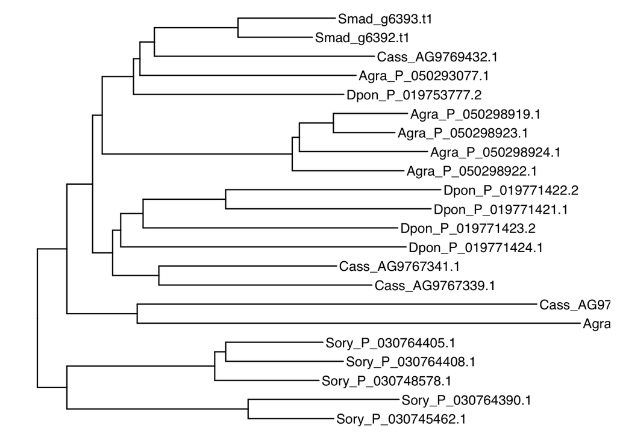

**(g6392, g6393)に#1を振った。**

**OG0000203**

```
# A tibble: 7 × 5
  qseqid sseqid   Orthogroup     evalue Sory_GeneFunction
  <chr>  <chr>    <chr>           <dbl> <chr>
1 e12    g9319.t1 OG0000203  0.00000438 UDP-glucuronosyltransferase 1-9-like
2 e12    g9322.t1 OG0000203  0.00000451 UDP-glucuronosyltransferase 1-9-like
3 e12    g9321.t1 OG0000203  0.0000226  UDP-glucuronosyltransferase 1-9-like
4 e14    g9321.t1 OG0000203  0.00000126 UDP-glucuronosyltransferase 1-9-like
5 e14    g9319.t1 OG0000203  0.00000275 UDP-glucuronosyltransferase 1-9-like
6 e14    g9322.t1 OG0000203  0.0000028  UDP-glucuronosyltransferase 1-9-like
7 e16    g9319.t1 OG0000203  0.0000215  UDP-glucuronosyltransferase 1-9-like
```

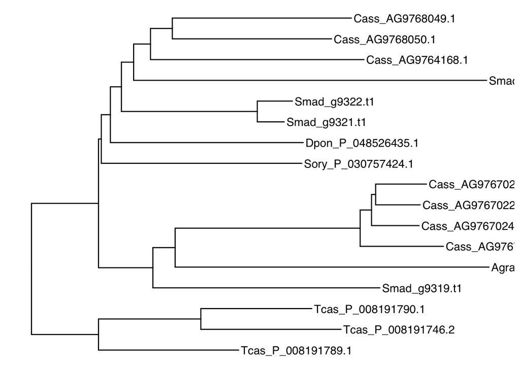

**(g9321, g9322)、g9319に#1を振った。別でg9323(アノテーションのつかなかったほう)だけの解析をしてもいいかも。**

**OG0000572**

```
# A tibble: 8 × 5
  qseqid sseqid   Orthogroup   evalue Sory_GeneFunction
  <chr>  <chr>    <chr>         <dbl> <chr>
1 e12    g6542.t1 OG0000572  1.13e- 7 UDP-glucuronosyltransferase 2B13-like
2 e12    g6541.t1 OG0000572  5.47e- 6 UDP-glucuronosyltransferase 2B13-like
3 e13    g6542.t1 OG0000572  9.55e- 6 UDP-glucuronosyltransferase 2B13-like
4 e14    g6542.t1 OG0000572  4.42e-11 UDP-glucuronosyltransferase 2B13-like
5 e14    g6541.t1 OG0000572  7.08e-10 UDP-glucuronosyltransferase 2B13-like
6 e15    g6542.t1 OG0000572  6.22e- 8 UDP-glucuronosyltransferase 2B13-like
7 e16    g6542.t1 OG0000572  4.22e-10 UDP-glucuronosyltransferase 2B13-like
8 e16    g6541.t1 OG0000572  7.21e- 8 UDP-glucuronosyltransferase 2B13-like
```

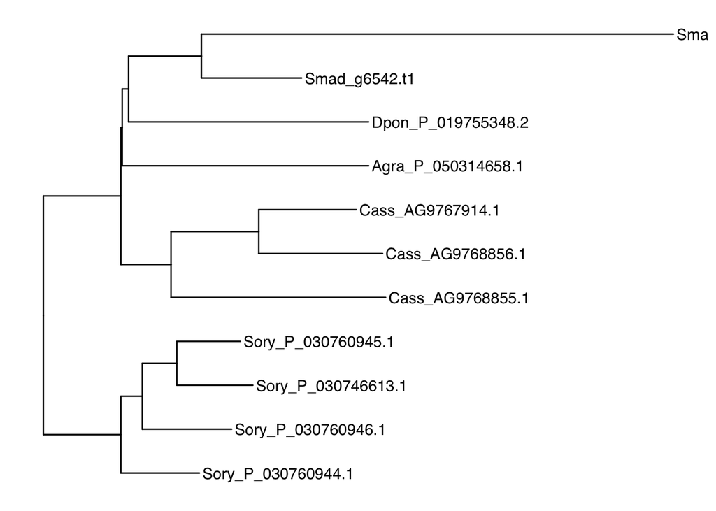

**g6541に#1を振った。**

**OG0000584**

```
# A tibble: 10 × 5
   qseqid sseqid   Orthogroup       evalue Sory_GeneFunction
   <chr>  <chr>    <chr>             <dbl> <chr>
 1 e12    g396.t1  OG0000584  0.0000000485 2-hydroxyacylsphingosine 1-beta-gala…
 2 e12    g8427.t1 OG0000584  0.000000177  2-hydroxyacylsphingosine 1-beta-gala…
 3 e13    g8427.t1 OG0000584  0.00000362   2-hydroxyacylsphingosine 1-beta-gala…
 4 e13    g396.t1  OG0000584  0.00000391   2-hydroxyacylsphingosine 1-beta-gala…
 5 e14    g396.t1  OG0000584  0.0000000649 2-hydroxyacylsphingosine 1-beta-gala…
 6 e14    g8427.t1 OG0000584  0.000000872  2-hydroxyacylsphingosine 1-beta-gala…
 7 e15    g396.t1  OG0000584  0.000000156  2-hydroxyacylsphingosine 1-beta-gala…
 8 e15    g8427.t1 OG0000584  0.000000271  2-hydroxyacylsphingosine 1-beta-gala…
 9 e16    g396.t1  OG0000584  0.000000283  2-hydroxyacylsphingosine 1-beta-gala…
10 e16    g8427.t1 OG0000584  0.000000403  2-hydroxyacylsphingosine 1-beta-gala…
```

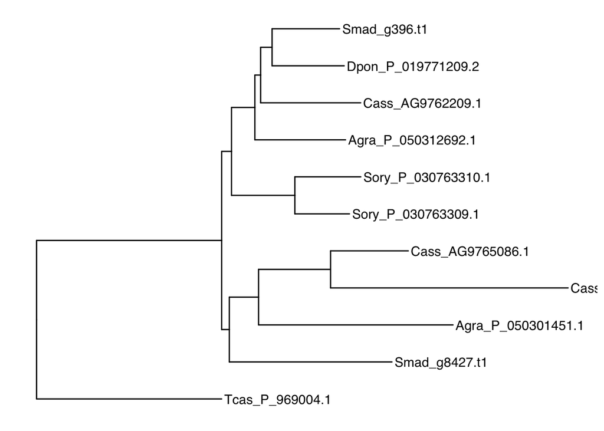

**g8427, g396に#1を振った**

**OG0000587**

```
# A tibble: 1 × 5
  qseqid sseqid  Orthogroup      evalue Sory_GeneFunction
  <chr>  <chr>   <chr>            <dbl> <chr>
1 e8     g405.t1 OG0000587  0.000000128 S-methyl-5'-thioadenosine phosphorylase…
```

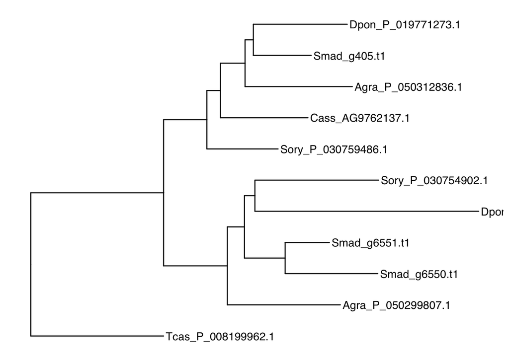

**g405に#1を振った。別でg6550, g6551(アノテーションのつかなかったほう)だけの解析をしてもいいかも。**

**OG0000755**

```
# A tibble: 2 × 5
  qseqid sseqid   Orthogroup    evalue Sory_GeneFunction
  <chr>  <chr>    <chr>          <dbl> <chr>
1 e8     g6207.t1 OG0000755  2.62e-112 purine nucleoside phosphorylase-like iso…
2 e8     g6208.t1 OG0000755  1.85e-103 purine nucleoside phosphorylase-like iso…
```

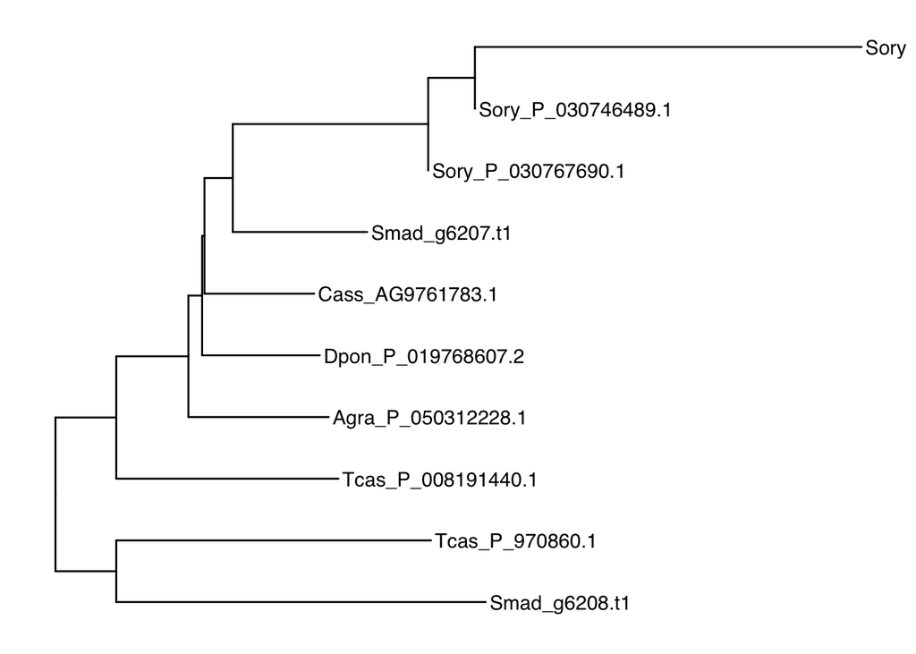

**OG0001251**

```
# A tibble: 1 × 5
  qseqid sseqid   Orthogroup   evalue Sory_GeneFunction
  <chr>  <chr>    <chr>         <dbl> <chr>
1 e5     g2065.t1 OG0001251  5.10e-32 protein 5NUC-like, partial
```

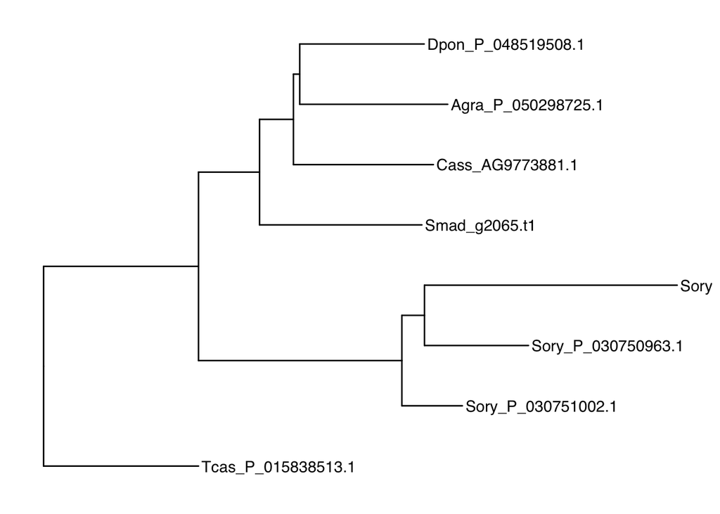

**g2065に#1を振った**

***OG0001494**

```
# A tibble: 1 × 5
  qseqid sseqid   Orthogroup    evalue Sory_GeneFunction
  <chr>  <chr>    <chr>          <dbl> <chr>
1 e9     g1876.t1 OG0001494  2.56e-147 adenosine kinase
```

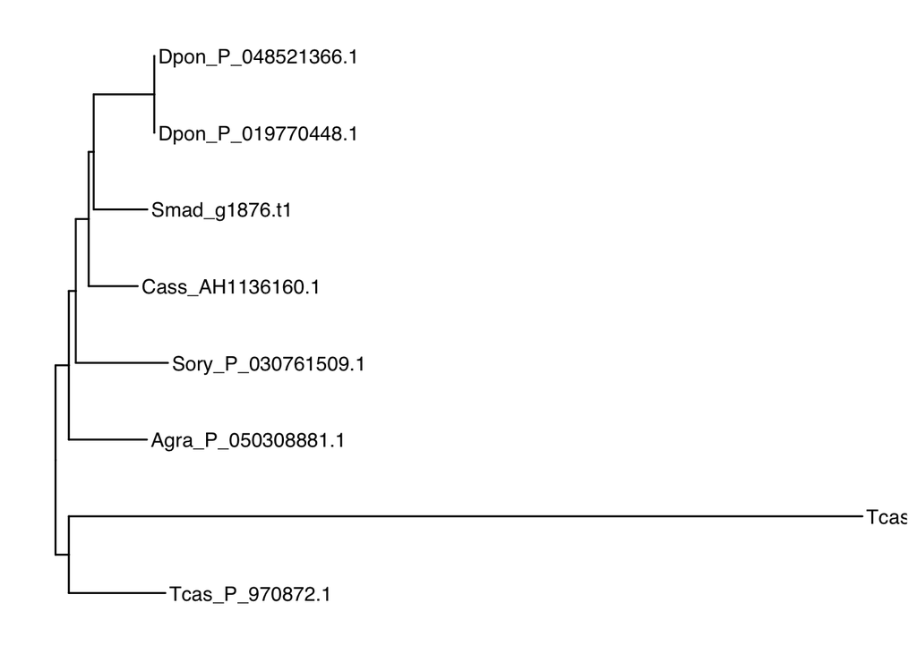

**g1876に#1を振った**

**OG0003285**

```
# A tibble: 16 × 5
   qseqid sseqid   Orthogroup   evalue Sory_GeneFunction
   <chr>  <chr>    <chr>         <dbl> <chr>
 1 e12    g4172.t1 OG0003285  1.62e- 8 UDP-glucuronosyltransferase 2B15-like
 2 e12    g4169.t1 OG0003285  8.65e- 6 UDP-glucuronosyltransferase 2B15-like
 3 e12    g6414.t2 OG0003285  1.06e- 5 UDP-glucuronosyltransferase 2B15-like
 4 e13    g4172.t1 OG0003285  4.40e- 6 UDP-glucuronosyltransferase 2B15-like
 5 e14    g4172.t1 OG0003285  2.02e-10 UDP-glucuronosyltransferase 2B15-like
 6 e14    g4170.t1 OG0003285  3.56e- 8 UDP-glucuronosyltransferase 2B15-like
 7 e14    g4171.t1 OG0003285  4.50e- 8 UDP-glucuronosyltransferase 2B15-like
 8 e14    g6414.t2 OG0003285  8.37e- 8 UDP-glucuronosyltransferase 2B15-like
 9 e14    g4169.t1 OG0003285  1.88e- 7 UDP-glucuronosyltransferase 2B15-like
10 e15    g4172.t1 OG0003285  5.09e- 8 UDP-glucuronosyltransferase 2B15-like
11 e15    g4169.t1 OG0003285  5.08e- 6 UDP-glucuronosyltransferase 2B15-like
12 e16    g4172.t1 OG0003285  2.64e- 8 UDP-glucuronosyltransferase 2B15-like
13 e16    g4170.t1 OG0003285  5.03e- 8 UDP-glucuronosyltransferase 2B15-like
14 e16    g4171.t1 OG0003285  1.32e- 7 UDP-glucuronosyltransferase 2B15-like
15 e16    g4169.t1 OG0003285  8.37e- 7 UDP-glucuronosyltransferase 2B15-like
16 e16    g6414.t2 OG0003285  6.89e- 6 UDP-glucuronosyltransferase 2B15-like
```

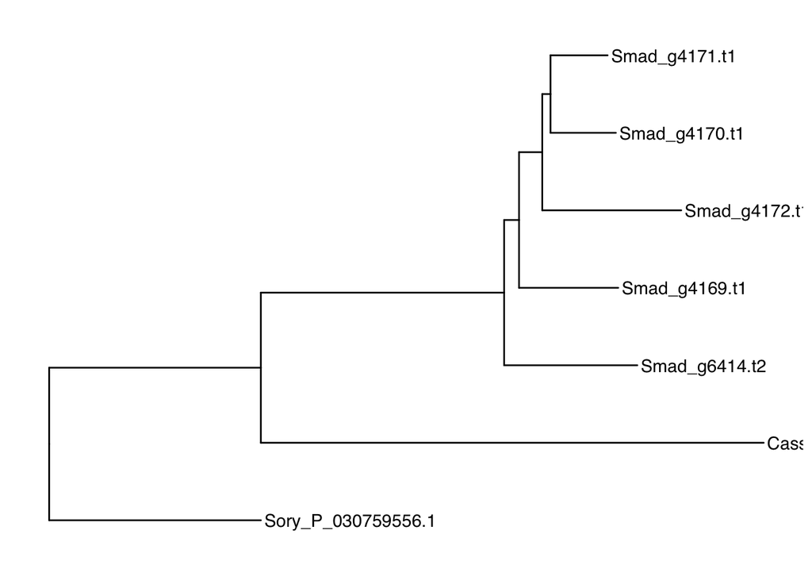

**マダラ枝基部に#1を振った**

**OG0003486**

```
# A tibble: 3 × 5
  qseqid sseqid   Orthogroup    evalue Sory_GeneFunction
  <chr>  <chr>    <chr>          <dbl> <chr>
1 e1_1   g6098.t1 OG0003486  8.69e-  6 tRNA dimethylallyltransferase isoform X1
2 e1_2   g6098.t1 OG0003486  9.27e- 22 tRNA dimethylallyltransferase isoform X1
3 e2     g6098.t1 OG0003486  8.39e-115 tRNA dimethylallyltransferase isoform X1
```

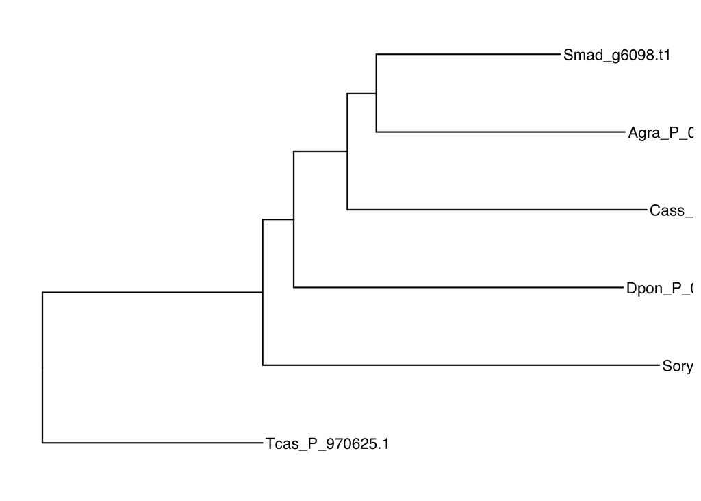

**g6098に#1を振った**

**OG003982**

```
# A tibble: 2 × 5
  qseqid sseqid   Orthogroup        evalue Sory_GeneFunction
  <chr>  <chr>    <chr>              <dbl> <chr>
1 e12    g1104.t1 OG0003982  0.00000616    2-hydroxyacylsphingosine 1-beta-gala…
2 e14    g1104.t1 OG0003982  0.00000000168 2-hydroxyacylsphingosine 1-beta-gala…
```

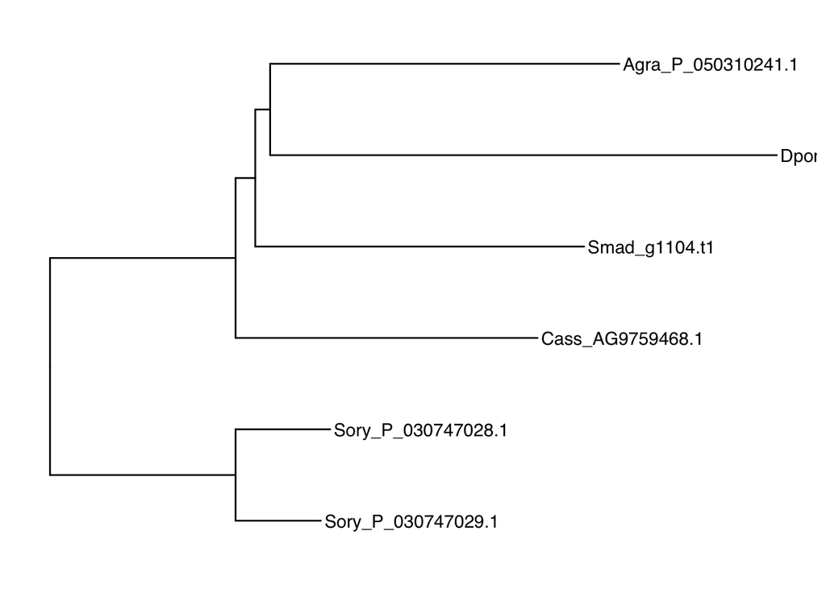

**g1104に#1を振った**

**OG0004173**

```
# A tibble: 1 × 5
  qseqid sseqid   Orthogroup evalue Sory_GeneFunction
  <chr>  <chr>    <chr>       <dbl> <chr>
1 e5     g8991.t1 OG0004173       0 protein 5NUC
```

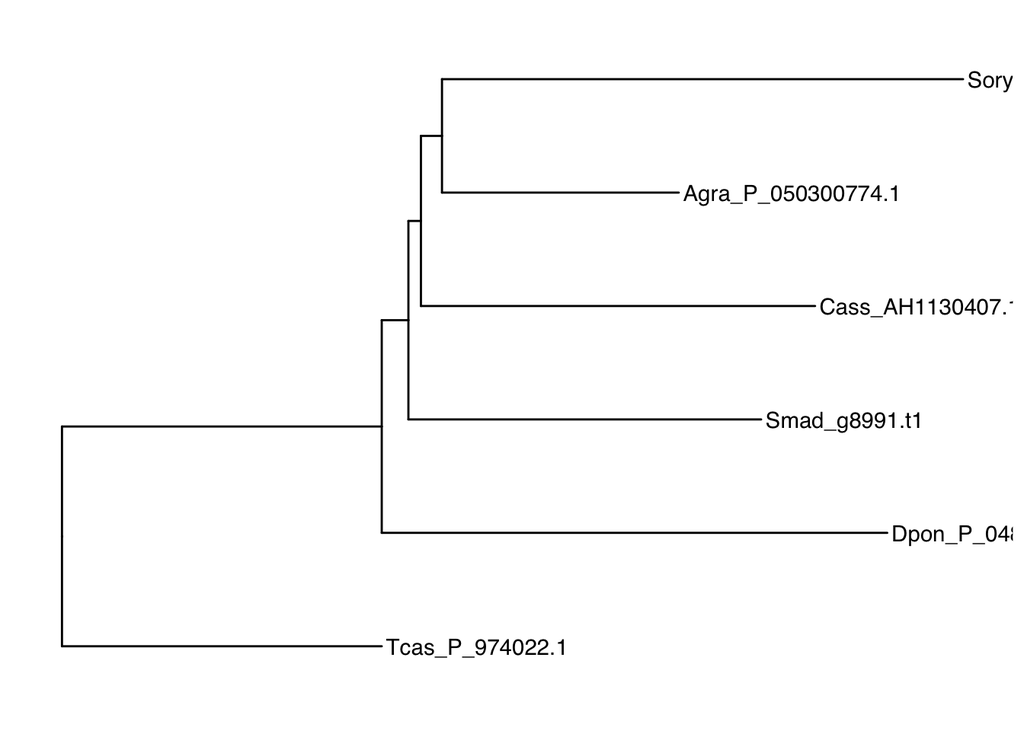

**g8991に#1を振った**

**OG0005024**

```
# A tibble: 1 × 5
  qseqid sseqid   Orthogroup   evalue Sory_GeneFunction
  <chr>  <chr>    <chr>         <dbl> <chr>
1 e3     g6011.t1 OG0005024  3.28e-40 threonylcarbamoyladenosine tRNA methylthi…
```

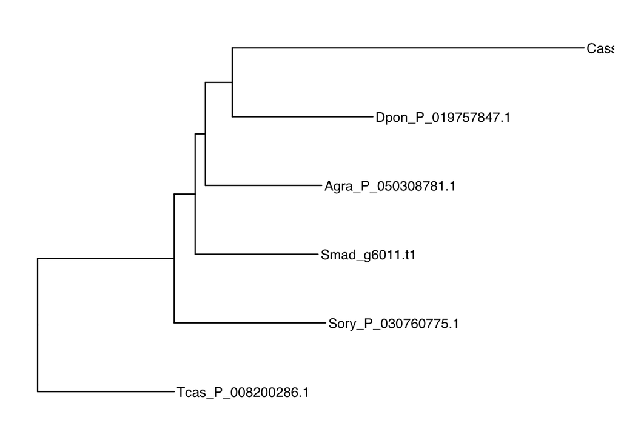

**g6011に#1を振った**

**OG0006816**

```
# A tibble: 1 × 5
  qseqid sseqid   Orthogroup       evalue Sory_GeneFunction
  <chr>  <chr>    <chr>             <dbl> <chr>
1 e17    g5362.t1 OG0006816  0.0000000268 delta(24)-sterol reductase-like
```

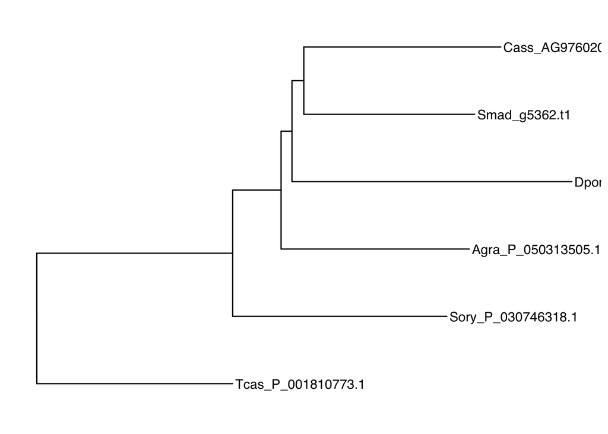

**g5362に#1を振った**

**OG0008087**

```
# A tibble: 3 × 5
  qseqid sseqid    Orthogroup       evalue Sory_GeneFunction
  <chr>  <chr>     <chr>             <dbl> <chr>
1 e13    g11571.t1 OG0008087  0.0000485    UDP-glucuronosyltransferase 2C1-like
2 e14    g11571.t1 OG0008087  0.0000119    UDP-glucuronosyltransferase 2C1-like
3 e16    g11571.t1 OG0008087  0.0000000322 UDP-glucuronosyltransferase 2C1-like
```

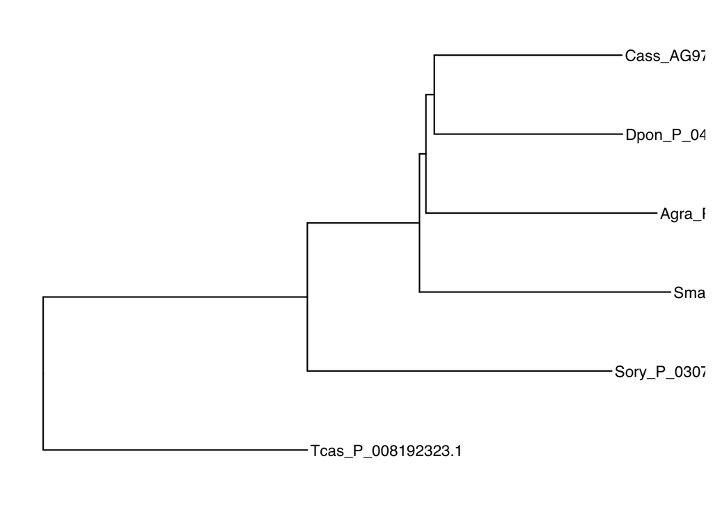

**g11571に#1を振った**

**OG0008328**

```
# A tibble: 1 × 5
  qseqid sseqid   Orthogroup   evalue Sory_GeneFunction
  <chr>  <chr>    <chr>         <dbl> <chr>
1 e3     g1799.t1 OG0008328  1.61e-74 CDK5RAP1-like protein
```

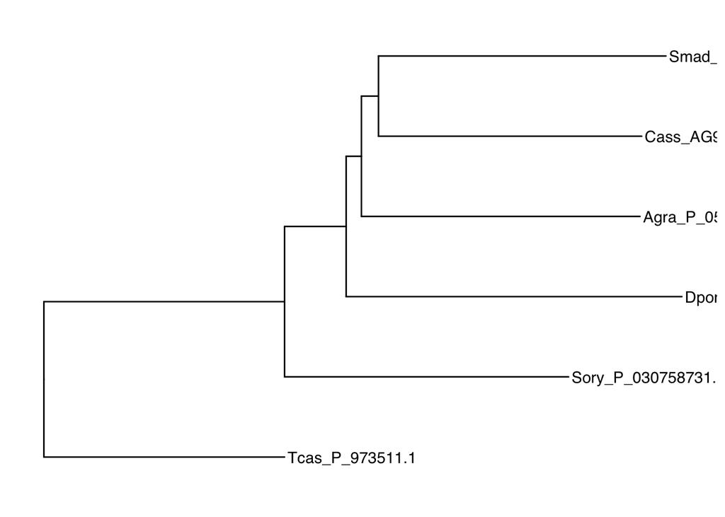

**g1799に#1を振った**

**OG0009811**

```
# A tibble: 1 × 5
  qseqid sseqid   Orthogroup   evalue Sory_GeneFunction
  <chr>  <chr>    <chr>         <dbl> <chr>
1 e9     g3375.t1 OG0009811  2.15e-51 adenosine kinase-like
```

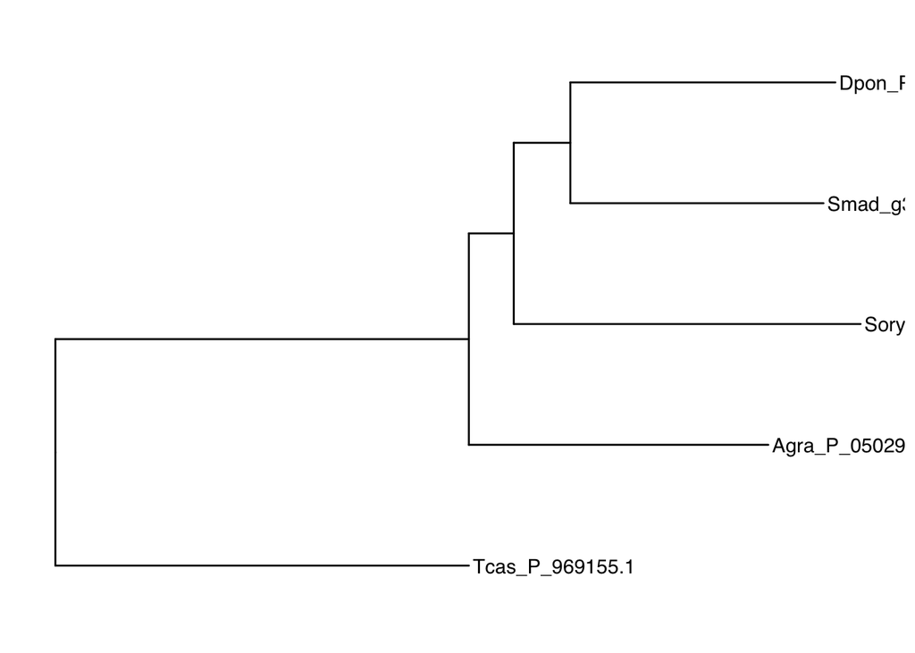

**g3375に#1を振った**

**OG0010036**

```
# A tibble: 1 × 5
  qseqid sseqid    Orthogroup   evalue Sory_GeneFunction
  <chr>  <chr>     <chr>         <dbl> <chr>
1 e10    g11508.t1 OG0010036  3.82e-56 adenine phosphoribosyltransferase
```

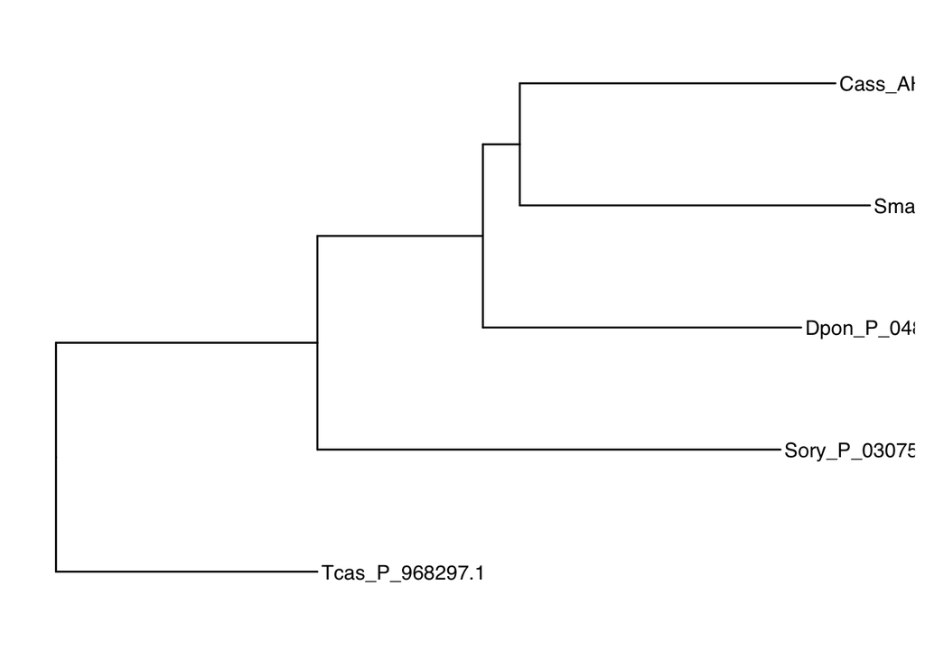

**g11508に#1を振った**

#### `codeML`の実行

`/home/kosukesano/tools/for_paml/250210_tRNA/paml/bsA`を作成、その下で以下を実行した。

```bash
### /home/kosukesano/tools/for_paml/250210_tRNA/paml/bsA/bsA.sh

#!/bin/bash

#$ -S /bin/bash
#$ -cwd
#$ -l gpu

# ディレクトリの設定
input_dir="/home/kosukesano/tools/for_paml/250210_tRNA/PRANK_CDS_plusN"
bsA_dir="/home/kosukesano/tools/for_paml/250210_tRNA/paml/bsA"
result_dir="$bsA_dir/result"
template_ctl="$bsA_dir/template.ctl"
tree_dir="/home/kosukesano/tools/for_paml/250210_tRNA/paml/tree"

# 出力ディレクトリが存在しない場合は作成
mkdir -p "$result_dir"

# テンプレートの制御ファイルを読み込む
ctl_template=$(cat "$template_ctl")

# ディレクトリ内の_pranked.fna.best.fasファイルを処理
for file in "$input_dir"/*_pranked.fna.best.fas; do
  if [[ -f "$file" ]]; then
    base_name=$(basename "$file" _pranked.fna.best.fas)
    treefile="$tree_dir/${base_name}_tree.txt"
    outfile_path="$result_dir/${base_name}_branch_alt"

    if [[ -f "$treefile" ]]; then
      # 一時的な制御ファイルの内容を生成
      ctl_content="${ctl_template//<SEQFILE>/$file}"
      ctl_content="${ctl_content//<OUTFILE>/$outfile_path}"
      ctl_content="${ctl_content//<TREEFILE>/$treefile}"

      # 一時的な制御ファイルを作成
      ctl_path="$bsA_dir/bsA.ctl"
      echo "$ctl_content" > "$ctl_path"

      # PAMLを実行
      singularity exec -e /usr/local/biotools/p/paml:4.9--h779adbc_6 codeml "$ctl_path"

      echo "Processed file: $file, output: $outfile_path, tree: $treefile"
    else
      echo "Tree file not found for OG: $base_name, skipping..."
    fi
  fi
done
```

対応するツリーファイルを持ってきてインプットにするよう改造してある。

コントロールファイルはこれ。

```bash
### template.ctl

seqfile = <SEQFILE>
treefile = <TREEFILE>
outfile = <OUTFILE>

noisy = 9
verbose = 1
runmode = 0
seqtype = 1
CodonFreq = 2
clock = 0
model = 2
NSsites = 2
fix_omega = 0
omega = 1
icode = 0
fix_kappa = 0
kappa = 2
fix_alpha = 1
alpha = .0
Malpha = 0
ncatG = 4
getSE = 0
RateAncestor = 0
method = 0
fix_blength = 0
```

#### `PRANK`のジョブ分割

```bash
kosukesano@at138:~/tools/for_paml/data/250211_6sp/PRANK_JobSplit$ ls
OG3                      OG4_prank.sh.o27481954   OG6                      OG7_prank.sh.o27482416   result
OG3_prank.sh             OG4_prank.sh.pe27481954  OG6_prank.sh             OG7_prank.sh.pe27482416  tmpdirprankmsa7JbftE
OG3_prank.sh.e27481953   OG4_prank.sh.po27481954  OG6_prank.sh.e27482414   OG7_prank.sh.po27482416  tmpdirprankmsaRbVqPw
OG3_prank.sh.o27481953   OG5                      OG6_prank.sh.o27482414   OG8                      tmpdirprankmsaW2xMSs
OG3_prank.sh.pe27481953  OG5_prank.sh             OG6_prank.sh.pe27482414  OG8_prank.sh             tmpdirprankmsaXBGv9N
OG3_prank.sh.po27481953  OG5_prank.sh.e27481959   OG6_prank.sh.po27482414  OG8_prank.sh.e27482419   tmpdirprankmsacixS76
OG4                      OG5_prank.sh.o27481959   OG7                      OG8_prank.sh.o27482419   tmpdirprankmsagMwQbf
OG4_prank.sh             OG5_prank.sh.pe27481959  OG7_prank.sh             OG8_prank.sh.pe27482419  tmpdirprankmsamYTcJt
OG4_prank.sh.e27481954   OG5_prank.sh.po27481959  OG7_prank.sh.e27482416   OG8_prank.sh.po27482419  tmpdirprankmsawE2tXx
kosukesano@at138:~/tools/for_paml/data/250211_6sp/PRANK_JobSplit$ ls result/
OG0003316_pranked.fna.best.fas  OG0003323_pranked.fna.best.fas  OG0005004_pranked.fna.best.fas  OG0006005_pranked.fna.best.fas
OG0003318_pranked.fna.best.fas  OG0004000_pranked.fna.best.fas  OG0005005_pranked.fna.best.fas  OG0007000_pranked.fna.best.fas
OG0003319_pranked.fna.best.fas  OG0004001_pranked.fna.best.fas  OG0005006_pranked.fna.best.fas  OG0007001_pranked.fna.best.fas
OG0003320_pranked.fna.best.fas  OG0005000_pranked.fna.best.fas  OG0005007_pranked.fna.best.fas  OG0008000_pranked.fna.best.fas
OG0003321_pranked.fna.best.fas  OG0005002_pranked.fna.best.fas  OG0006001_pranked.fna.best.fas
OG0003322_pranked.fna.best.fas  OG0005003_pranked.fna.best.fas  OG0006002_pranked.fna.best.fas
kosukesano@at138:~/tools/for_paml/data/250211_6sp/PRANK_JobSplit$
```

### 0217

#### isoformを抜いた6種甲虫での`CAFE5`

`OrthoFinder`の出力から、`Orthogroups/`ディレクトリと`Species_Tree/`ディレクトリをローカルにコピーした。

```bash
(base) :~/bio/for_cafe/250128_Ortho_data$ ls Orthogroups/
Orthogroups.GeneCount.tsv             Orthogroups_SingleCopyOrthologues.txt
Orthogroups.tsv                       Orthogroups_UnassignedGenes.tsv
Orthogroups.txt
(base) :~/bio/for_cafe/250128_Ortho_data$
(base) :~/bio/for_cafe/250128_Ortho_data$ ls Species_Tree/
SpeciesTree_rooted.txt             SpeciesTree_rooted_node_labels.txt
(base) :~/bio/for_cafe/250128_Ortho_data$
```

[output not shown]

この結果はこんな感じ

```bash
(base) :~/bio/for_cafe/250128_Ortho_data$ ls Processed_data/
Orthogroups.GeneCount2.tsv tree_ultrametric.nwk
(base) :~/bio/for_cafe/250128_Ortho_data$
```

これを遺伝研にコピー

```bash
kosukesano@at137:~/tools/for_cafe/250217_6sp_iso1$ ls data/
Orthogroups.GeneCount2.tsv  tree_ultrametric.nwk
kosukesano@at137:~/tools/for_cafe/250217_6sp_iso1$
```

`CAFE5`の実行

```bash
kosukesano@at137:~/tools/for_cafe/250217_6sp_iso1$ singularity exec -e /usr/local/biotools/c/cafe:5.0.0--h5b5514e_2 cafe5 -i data/Orthogroups.GeneCount2.tsv -t data/tree_ultrametric.nwk

Command line: /usr/local/bin/cafe5 -i data/Orthogroups.GeneCount2.tsv -t data/tree_ultrametric.nwk

Filtering families not present at the root from: 7627 to 4567

No root family size distribution specified, using uniform distribution

Optimizer strategy: Nelder-Mead with similarity cutoff
Iterations: 300
Expansion: 2
Reflection: 1

Starting Search for Initial Parameter Values
Lambda: 0.0020832402953942
Score (-lnL): 52268.463510308
Lambda: 0.0020832402953942
.
.
.
```

出力はこう

```bash
kosukesano@at137:~/tools/for_cafe/250217_6sp_iso1$ ls results/
Base_asr.tre                   Base_change.tab         Base_count.tab               Base_family_results.txt
Base_branch_probabilities.tab  Base_clade_results.txt  Base_family_likelihoods.txt  Base_results.txt
kosukesano@at137:~/tools/for_cafe/250217_6sp_iso1$
```

これをまたローカルに戻す

```bash
(base) :~/bio/for_cafe$ ls 250217_cafe_data/
Base_asr.tre                  Base_clade_results.txt        Base_family_results.txt
Base_branch_probabilities.tab Base_count.tab                Base_results.txt
Base_change.tab               Base_family_likelihoods.txt
(base) :~/bio/for_cafe$
```

### 0221

#### CK関連遺伝子における、正の選択が検出されたサイト

`PRANK`でアライメントし、ギャップを全て除去したデータで`codeML`をかけたが、遺伝子全体での正の選択は検出されなかった。しかしサイト別ではあったので、洗い出してみる。

**OG0000755**

```bash
Bayes Empirical Bayes (BEB) analysis (Yang, Wong & Nielsen 2005. Mol. Biol. Evol. 22:1107-1118)
Positive sites for foreground lineages Prob(w>1):
```

なし？

**OG0001494**

```bash
Bayes Empirical Bayes (BEB) analysis (Yang, Wong & Nielsen 2005. Mol. Biol. Evol. 22:1107-1118)
Positive sites for foreground lineages Prob(w>1):
     7 H 0.560
   122 V 0.869
   181 S 0.937
   208 N 0.899
   282 A 0.673
```

181番のSが高い。

**OG0003486**

```bash
Bayes Empirical Bayes (BEB) analysis (Yang, Wong & Nielsen 2005. Mol. Biol. Evol. 22:1107-1118)
Positive sites for foreground lineages Prob(w>1):
   169 H 0.526
   271 A 0.658
   401 A 0.759
```

**OG0004173**

```bash
Bayes Empirical Bayes (BEB) analysis (Yang, Wong & Nielsen 2005. Mol. Biol. Evol. 22:1107-1118)
Positive sites for foreground lineages Prob(w>1):
```

なし？

**OG0008328**

```bash
Bayes Empirical Bayes (BEB) analysis (Yang, Wong & Nielsen 2005. Mol. Biol. Evol. 22:1107-1118)
Positive sites for foreground lineages Prob(w>1):
   458 E 0.943
   519 S 0.806
   540 I 0.799
   558 Y 0.633
```

458のEが高い

**OG0010036**

```bash
Bayes Empirical Bayes (BEB) analysis (Yang, Wong & Nielsen 2005. Mol. Biol. Evol. 22:1107-1118)
Positive sites for foreground lineages Prob(w>1):
     6 I 0.556
     9 I 0.506
    11 A 0.873
    22 P 0.551
    29 L 0.550
    35 K 0.932
    37 E 0.678
    45 V 0.678
    80 I 0.750
   158 L 0.980*
```

35番目のKと158番目のLが高め。

### 0224

`pymol`のインストール

alphafold3の結果を可視化するツール

```bash
(base) :~/pyenv_conda_environment$ conda create -n pymol
Channels:
 - conda-forge
Platform: osx-64
Collecting package metadata (repodata.json): done
Solving environment: done


==> WARNING: A newer version of conda exists. <==
    current version: 23.10.0
    latest version: 25.1.1

Please update conda by running

    $ conda update -n base -c conda-forge conda



## Package Plan ##

  environment location: /Users/kosukesano/.pyenv/versions/mambaforge-23.10.0-0/envs/pymol



Proceed ([y]/n)? y

Preparing transaction: done
Verifying transaction: done
Executing transaction: done
#
# To activate this environment, use
#
#     $ conda activate pymol
#
# To deactivate an active environment, use
#
#     $ conda deactivate

(base) :~/pyenv_conda_environment$
(base) :~/pyenv_conda_environment$ conda activate pymol
(pymol) :~/pyenv_conda_environment$ conda install -c schrodinger pymol
Channels:
 - schrodinger
 - conda-forge
Platform: osx-64
Collecting package metadata (repodata.json): |
done
Solving environment: done

.
.
.
.
.

Downloading and Extracting Packages:

Preparing transaction: done
Verifying transaction: done
Executing transaction: done
(pymol) :~/pyenv_conda_environment$


(pymol) :~/pyenv_conda_environment$ conda install pyqt

Channels:
 - conda-forge
 - schrodinger
Platform: osx-64
Collecting package metadata (repodata.json): done
Solving environment: done
.
.
.
.
.

Proceed ([y]/n)?

Downloading and Extracting Packages:

Preparing transaction: done
Verifying transaction: done
Executing transaction: done
(pymol) :~/pyenv_conda_environment$
```

これでコマンドラインで`pymol`と打つと、`pymol`のコマンドラインが立ち上がる。